# EDA 71 — LOP Outcome Profile: Distribution Structure for Statistical Modeling

Frequency, Zero-Inflation, and Tail Behaviour of LOP Absence Day Outcomes

Author

Analysis Team

Published

June 19, 2026

# Mission

This EDA characterizes the distributional properties of the LOP (Loss of Productivity) outcome variables to build intuition for statistical models that use these measures as criterion variables. Where EDA-5 decomposed the LOP components into their prevalence and contribution profiles, EDA-71 focuses on the **modeling-context lens**: the shape of the frequency distribution across day-count bins, zero-inflation severity, the composite outcome’s heavy-tail structure, and inter-component correlation.

**Research Questions:**

1. How does each of the 8 LOP component variables distribute across positive day-count bins? How do the marginal-prevalence curves differ in height (overall positive prevalence) and in tail decay (how quickly they drop with increasing day count)?
2. What is the zero-inflation fraction for each LOP component — and how does it differ across the 8 reasons?
3. How does the composite outcome `days_absent_total` distribute — its zero mass, right-tail shape, and key quantiles?
4. How correlated are the 8 LOP components, and what does this imply for using the total as a single model criterion?

> **Bootstrap weights note**: Confidence intervals via bootstrap are not available for CCHS 2010 and 2014 PUMF cycles. All variance-sensitive summaries use the pooled master weight (`wts_m_pooled`) only. See CACHE manifest.

Following the dual-file development pattern, all analytical code lives in `analysis/eda-71/eda-71.R`. This document sources those chunks for presentation.

# Definition of Terms

**LOP module**: Loss of Productivity module from the CCHS. Respondents are asked how many workdays they missed in the past 3 months due to each of 8 distinct health-related reasons.

**`days_absent_total`**: The primary outcome. Row-wise sum of all 8 LOP component variables (`lopg040` + `lopg070` + `lopg082`–`lopg086` + `lopg100`), capped at 90 days.

**`days_absent_chronic`**: The sensitivity outcome. Days missed due to chronic condition only (`lopg040`), capped at 90 days.

**Marginal prevalence**: In this EDA, “prevalence at bin *k*” means the weighted percentage of **all** respondents (including those with zero days for that reason) who fall in bin *k*. Zero-day respondents are included in the denominator, giving population-level marginal probabilities rather than conditional-on-reporter proportions.

**Zero-inflation**: The structural over-representation of zero responses. In the LOP context, zero is a valid response (the respondent was employed but missed no days for that reason). It is not missing data. The distinction is confirmed in Ellis pipeline step 4 and validated in EDA-5/G6.

**LOP reason categories (8 components):**

| Variable | Reason |
| --- | --- |
| `lopg040` | Own chronic condition |
| `lopg070` | Injury |
| `lopg082` | Cold |
| `lopg083` | Flu / influenza |
| `lopg084` | Gastroenteritis (stomach flu) |
| `lopg085` | Respiratory infection |
| `lopg086` | Other infectious disease |
| `lopg100` | Other physical / mental health reason |

# Environment

```
Loaded: 63,843 rows, 70 columns
```

# Data Context

For complete data documentation, see the Data Primer.

```
# A tibble: 1 × 5
  source_table          location                                                  rows columns usage
  <chr>                 <chr>                                                    <int>   <int> <chr>
1 cchs_analytic.parquet ./data-private/derived/cchs-2-tables/cchs_analytic.parq… 63843      70 All …
```

```
# A tibble: 2 × 12
  cchs_cycle_f wts_m_pooled days_absent_total days_absent_chronic lopg040 lopg070 lopg082 lopg083
  <fct>               <dbl>             <dbl>               <dbl>   <dbl>   <dbl>   <dbl>   <dbl>
1 2010-2011            488.                 5                   4       4       0       1       0
2 2010-2011           2589.                 4                   0       0       0       2       0
# ℹ 4 more variables: lopg084 <dbl>, lopg085 <dbl>, lopg086 <dbl>, lopg100 <dbl>
```

```
# A tibble: 8 × 6
  reason_label                   column  n_positive pct_positive mean_days median_days
  <chr>                          <chr>        <int>        <dbl>     <dbl>       <dbl>
1 Other physical / mental health lopg100       5379        8.43     0.320            0
2 Cold                           lopg082       5331        8.35     0.159            0
3 Chronic condition              lopg040       3626        5.68     0.414            0
4 Flu / influenza                lopg083       2462        3.86     0.0957           0
5 Injury                         lopg070       2219        3.48     0.235            0
6 Gastroenteritis                lopg084       2106        3.30     0.0596           0
7 Other infectious disease       lopg086        703        1.10     0.0319           0
8 Respiratory infection          lopg085        630        0.987    0.0352           0
```

Empirical distribution of observed values in the outcome

[output not shown]

# Analysis

## Opening Lens — What The Criterion Measures

Before reading displays `G1+`, anchor interpretation on what `days_absent_total` represents in this dataset:

1. It is a **3-month count outcome**: total work days missed in the past three months due to one of the 8 health-related reasons used to span health-related absentism in the LOP module.
2. It is analyzed with **pooled survey weight** `wts_m_pooled` (not raw `wts_m`) because two cycles are combined.
3. A weighted quantity is population-representative for the employed-worker target frame used by the LOP module.

This report uses two complementary perspectives that should be kept separate:

1. **Population burden perspective**: how much each reason contributes to total productivity loss in absolute and relative terms.
2. **Reporter intensity perspective**: among workers with non-zero days for a reason, how many days are typically lost and how variable that intensity is.

EDA-5 already provides the full decomposition workflow (prevalence, contribution, co-occurrence). Here we use a compact orientation visual so later graphs can be read with the right denominator logic.

Opening lens table: absolute and relative burden by reason (includes total outcome reference row)

| Reason | Prevalence (% with >=1 day) | Mean days per worker | Mean days among reporters | Days per 100 workers | Share of total days |
| --- | --- | --- | --- | --- | --- |
| Chronic condition | 5.29% | 0.366 | 6.92 | 36.58 | 29.39% |
| Injury | 3.40% | 0.213 | 6.26 | 21.26 | 17.08% |
| Cold | 8.52% | 0.156 | 1.83 | 15.58 | 12.51% |
| Flu / influenza | 3.70% | 0.090 | 2.45 | 9.04 | 7.27% |
| Gastroenteritis | 3.28% | 0.058 | 1.77 | 5.78 | 4.65% |
| Respiratory infection | 0.90% | 0.030 | 3.33 | 3.00 | 2.41% |
| Other infectious disease | 1.05% | 0.030 | 2.87 | 3.00 | 2.41% |
| Other physical / mental health | 8.18% | 0.302 | 3.70 | 30.23 | 24.28% |
| Total outcome | 28.92% | 1.245 | 4.30 | 124.47 | 100.00% |

### G0 — Criterion Orientation

Compact orientation map used as the denominator anchor for all downstream graph families.

**Script preview: g0 data preparation from ds0**

```r
# Perspective A (population burden): weighted expected days per worker in 3 months
# and each reason's relative share of total days_absent_total.
# Perspective B (reporter intensity): conditional mean among respondents with >0
# days for the specific reason.

g0_denom_w <- sum(ds0[[weight_col]], na.rm = TRUE)
g0_total_mean_days <- sum(ds0[[weight_col]] * ds0$days_absent_total, na.rm = TRUE) / g0_denom_w

g0_reason_summary <- ds_lop_long %>%
  group_by(reason_label) %>%
  summarise(
    weighted_prev_pct = sum(.data[[weight_col]] * (days_reason > 0), na.rm = TRUE) / g0_denom_w * 100,
    weighted_mean_days_per_worker = sum(.data[[weight_col]] * days_reason, na.rm = TRUE) / g0_denom_w,
    weighted_mean_days_among_reporters = dplyr::if_else(
      sum(.data[[weight_col]] * (days_reason > 0), na.rm = TRUE) > 0,
      sum(.data[[weight_col]] * days_reason, na.rm = TRUE) /
        sum(.data[[weight_col]] * (days_reason > 0), na.rm = TRUE),
      NA_real_
    ),
    .groups = "drop"
  ) %>%
  mutate(
    absolute_days_per_100_workers = weighted_mean_days_per_worker * 100,
    relative_share_pct = weighted_mean_days_per_worker / g0_total_mean_days * 100,
    reason_label = factor(reason_label, levels = lop_components)
  )

g0_total_row <- tibble::tibble(
  reason_label = factor("Total outcome", levels = c(lop_components, "Total outcome")),
  weighted_prev_pct = sum(ds0[[weight_col]] * (ds0$days_absent_total > 0), na.rm = TRUE) / g0_denom_w * 100,
  weighted_mean_days_per_worker = g0_total_mean_days,
  weighted_mean_days_among_reporters = sum(ds0[[weight_col]] * ds0$days_absent_total, na.rm = TRUE) /
    sum(ds0[[weight_col]] * (ds0$days_absent_total > 0), na.rm = TRUE),
  absolute_days_per_100_workers = g0_total_mean_days * 100,
  relative_share_pct = 100
)

g0_opening_table <- bind_rows(g0_reason_summary, g0_total_row) %>%
  mutate(
    reason_label = as.character(reason_label),
    weighted_prev_pct = sprintf("%.2f%%", weighted_prev_pct),
    weighted_mean_days_per_worker = sprintf("%.3f", weighted_mean_days_per_worker),
    weighted_mean_days_among_reporters = sprintf("%.2f", weighted_mean_days_among_reporters),
    absolute_days_per_100_workers = sprintf("%.2f", absolute_days_per_100_workers),
    relative_share_pct = sprintf("%.2f%%", relative_share_pct)
  )

if (isTRUE(getOption("knitr.in.progress"))) {
  knitr::kable(
    g0_opening_table,
    format = "html",
    col.names = c(
      "Reason",
      "Prevalence (% with >=1 day)",
      "Mean days per worker",
      "Mean days among reporters",
      "Days per 100 workers",
      "Share of total days"
    ),
    align = c("l", "r", "r", "r", "r", "r"),
    caption = "Opening lens table: absolute and relative burden by reason (includes total outcome reference row)"
  )
} else {
  print(g0_opening_table)
}
```

**Script preview: g0 graph construction**

```r
# Compact duality map: each point is one LOP reason.
# X = prevalence among workers; Y = average days among reporters.
# Point area = absolute burden (days per 100 workers), colour = relative share.
g0_duality_map <- g0_reason_summary %>%
  ggplot(aes(
    x = weighted_prev_pct,
    y = weighted_mean_days_among_reporters,
    size = absolute_days_per_100_workers,
    colour = relative_share_pct,
    label = reason_label
  )) +
  geom_hline(yintercept = mean(g0_reason_summary$weighted_mean_days_among_reporters, na.rm = TRUE),
             linewidth = 0.25, colour = "#7A7A7A", linetype = "dashed") +
  geom_vline(xintercept = mean(g0_reason_summary$weighted_prev_pct, na.rm = TRUE),
             linewidth = 0.25, colour = "#7A7A7A", linetype = "dashed") +
  geom_point(alpha = 0.9) +
  geom_text(size = 2.8, nudge_y = 0.06, check_overlap = TRUE) +
  scale_size_continuous(range = c(3, 11), name = "Days per 100 workers") +
  scale_colour_gradient(
    low = "#9BC6D9",
    high = "#0B4F6C",
    name = "Share of total days"
  ) +
  labs(
    title = "G0: Criterion orientation — burden vs intensity across LOP reasons",
    subtitle = paste0(
      "Weights: ", weight_col,
      ". All quantities refer to the past 3-month recall window among employed workers."
    ),
    x = "Prevalence (% with >=1 day)",
    y = "Mean days among reporters",
    caption = paste0(
      "Read points with two lenses: larger/darker = larger contribution to aggregate productivity loss; ",
      "higher y = longer episodes among affected workers."
    )
  ) +
  theme_minimal(base_size = 11) +
  theme(
    legend.position = "right",
    panel.grid.minor = element_blank(),
    plot.title.position = "plot"
  )

ggsave(
  paste0(prints_folder, "g0_duality_map.png"),
  g0_duality_map, width = 8.5, height = 5.5, dpi = 300
)
print(g0_duality_map)


# =============================================================================
# G1 FAMILY — Frequency Distribution Curves per LOP Reason
# Framing question: How does each LOP component variable distribute across
#   positive day-count bins?
# g1: marginal prevalence lines — one per reason, x = day-count bin, y = %
# =============================================================================
```

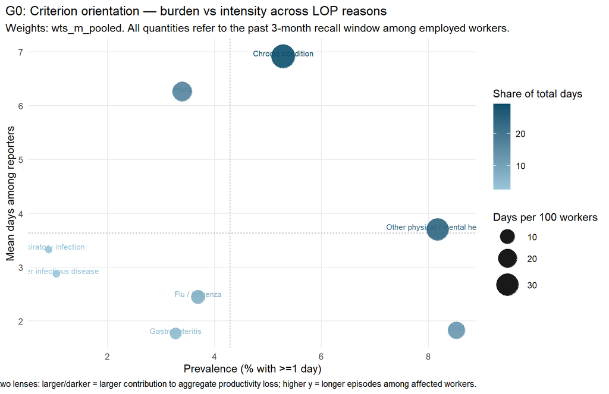

G0: Each point is one LOP reason. X-axis is weighted prevalence (% of workers with >=1 day), Y-axis is weighted mean days among reporters (>0), point size is absolute burden (days per 100 workers), and colour is relative share of total days_absent_total. This visual separates contribution (how much a reason matters at population level) from intensity (how severe episodes are among affected workers). For full decomposition details, see EDA-5.

### Chronic Condition — Concrete Interpretation of Each Opening-Lens Value

The chronic row should be read literally as a weighted population statement for the employed-worker frame in the LOP module.

Definition check against survey documentation:

1. The gate is employment in the past 3 months (`LOP_015`: “Did you work at a job or a business at any time in the past three months?”): data-private/derived/2026-02-19/CCHS_2014_DataDictionary_Freqs.txt.
2. Chronic-condition absence is asked as missed work days in the past 3 months due to chronic condition (`LOP_030` + derived `LOPG040`): data-private/derived/2026-02-19/CCHS_2014_DataDictionary_Freqs.txt, data-private/derived/2026-02-19/CCHS_2010_Record_Layout.txt.
3. The analytical criterion is the 8-component sum in Ellis (`days_absent_total = lopg040 + ... + lopg100`) with pooled weight usage (`wts_m_pooled = wts_m / 2`): manipulation/2-ellis.R, manipulation/2-ellis.R.

Chronic condition: concrete interpretation of each opening-lens value

| Metric | Value | Interpretation |
| --- | --- | --- |
| Prevalence among workers | 5.29% | Estimated 5.29% of employed workers had >=1 missed work day in the past 3 months due to a chronic condition. |
| Mean chronic days per worker | 0.366 days | Averaged across all employed workers (including those with 0 chronic-condition days), chronic condition contributes 0.366 lost days per worker over 3 months. |
| Mean chronic days among reporters | 6.92 days | Among workers with >=1 chronic-condition day, the mean intensity is 6.92 days lost over 3 months. |
| Burden per 100 workers | 36.58 days | Equivalent burden scale: 36.58 chronic-condition days lost per 100 employed workers over 3 months. |
| Share of total days_absent_total | 29.39% | Chronic condition accounts for 29.39% of total days_absent_total (all 8 reasons combined). |

## G1 — Frequency Distribution Curves per LOP Reason

**Framing question**: How does each of the 8 LOP component variables distribute across positive day-count bins?

### G1 — Marginal Prevalence Curves

Main cross-reason frequency shape comparison on the positive-day support.

**Script preview: g1 data preparation from ds_lop_long**

```r
# Bin each day count into ordered categories; compute weighted marginal prevalence.
# Y = weighted % of ALL respondents (including 0-day) at each positive bin.
# Denominator includes all respondents — giving population-level marginal probabilities.

g1_bin_data <- ds_lop_long %>%
  mutate(
    day_bin = dplyr::case_when(
      is.na(days_reason) | days_reason == 0 ~ NA_character_,
      days_reason == 1   ~ "1 day",
      days_reason == 2   ~ "2 days",
      days_reason == 3   ~ "3 days",
      days_reason == 4   ~ "4 days",
      days_reason == 5   ~ "5 days",
      days_reason <= 10  ~ "6\u201310 days",
      days_reason <= 15  ~ "11\u201315 days",
      days_reason <= 30  ~ "16\u201330 days",
      TRUE               ~ "31+ days"
    ),
    day_bin = factor(day_bin, levels = bin_levels)
  )

# Denominator: total weight per reason (all respondents, including zero-day)
g1_denom <- g1_bin_data %>%
  group_by(reason_label) %>%
  summarise(wt_total = sum(.data[[weight_col]], na.rm = TRUE), .groups = "drop")

g1_data <- g1_bin_data %>%
  filter(!is.na(day_bin)) %>%
  group_by(reason_label, day_bin) %>%
  summarise(
    wt_bin = sum(.data[[weight_col]], na.rm = TRUE),
    n_bin  = n(),
    .groups = "drop"
  ) %>%
  left_join(g1_denom, by = "reason_label") %>%
  mutate(pct_weighted = wt_bin / wt_total * 100)
```

**Script preview: g1 graph construction**

```r
# Line graph: each line traces the marginal-prevalence frequency distribution of
# one LOP component variable across ordered positive day-count bins.
# Reason: set2 palette (8 qualitative colours, printer-friendly).

g1_lop_freq_curves <- g1_data %>%
  ggplot(aes(
    x      = day_bin,
    y      = pct_weighted,
    colour = reason_label,
    group  = reason_label
  )) +
  geom_line(linewidth = 0.9) +
  geom_point(size = 2.2) +
  scale_y_continuous(
    labels = scales::label_percent(scale = 1),
    expand = expansion(mult = c(0, 0.08))
  ) +
  scale_colour_brewer(palette = "Set2", name = "Reason for absence") +
  labs(
    title   = "G1: Frequency distribution of absent days per LOP reason \u2014 marginal prevalence",
    subtitle = paste(
      "Y = weighted % of all workers in each positive bin (about cases per 100 workers).",
      "Summing bins for a reason gives its % with >=1 day.",
      sep = "\n"
    ),
    x       = "Days absent (frequency bin)",
    y       = "Weighted % of respondents",
    caption = paste(
      "Bins are collapsed in the upper tail (6\u201310, 11\u201315, 16\u201330, 31+) to stabilize sparse counts and preserve cross-reason shape comparability.",
      "Source: CCHS 2010\u201311 & 2013\u201314 pooled analytical sample (n = 63,843).",
      sep = "\n"
    )
  ) +
  theme_minimal(base_size = 11) +
  theme(
    axis.text.x      = element_text(angle = 35, hjust = 1),
    legend.position  = "bottom",
    legend.title     = element_text(size = 9),
    legend.text      = element_text(size = 8),
    panel.grid.minor = element_blank()
  ) +
  guides(colour = guide_legend(nrow = 2))

ggsave(
  paste0(prints_folder, "g1_lop_freq_curves.png"),
  g1_lop_freq_curves, width = 8.5, height = 5.5, dpi = 300
)
print(g1_lop_freq_curves)
```

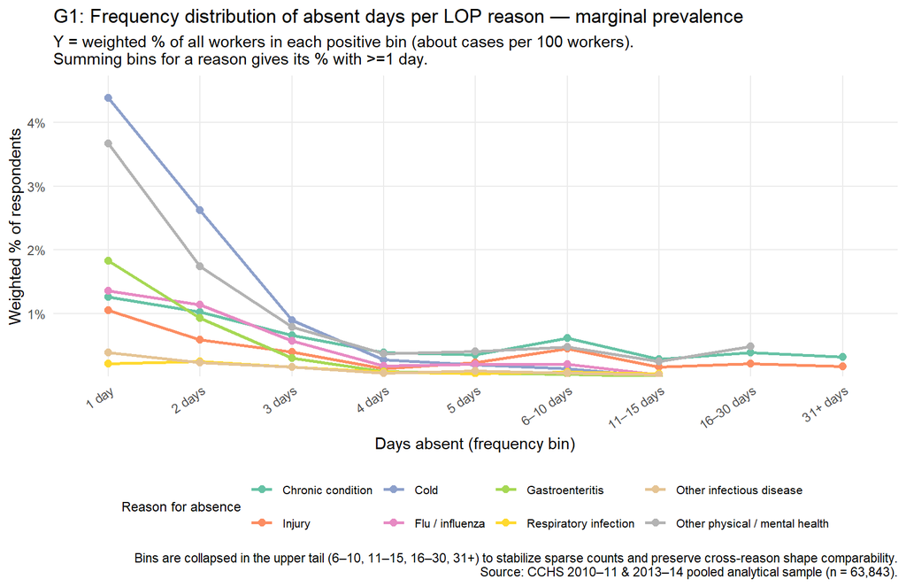

In G1, each point on a line is a **marginal prevalence** value: the weighted percentage of all employed workers who fall in that exact day bin for that reason. Zero-day workers are not plotted on the x-axis, but they remain in the denominator.

Practical reading rule:

1. A value of 1.0% at a bin means about 1 per 100 workers (or 10 per 1,000 workers) are in that bin for that reason.
2. A value of 0.25% means about 2.5 per 1,000 workers.

What should the points add up to?

1. For a given reason, summing all G1 y-values across the positive bins gives that reason’s positive prevalence from G0: `% with >=1 day`.
2. The sum does **not** equal 100%, because 0-day workers are in the denominator but excluded from plotted bins.

Why collapsed bins (`6–10`, `11–15`, `16–30`, `31+`) instead of integer days?

1. Tail counts are sparse at high day values for each reason, so single-day bins become unstable and visually noisy.
2. Collapsing preserves shape information needed for modeling (front-loaded vs heavy-tail) while improving comparability across 8 lines on one panel.
3. This is intentional contrast with EDA-5 G01, where the focus was the single composite outcome and integer-level detail among `>=1` reporters.

Interpretive pattern:

1. Higher first-bin points indicate more common short absences at population level.
2. Slower decay into upper bins indicates heavier tails and more prolonged episodes.

### G11 — Faceted Shape Benchmarks for Each LOP Variable (plus Total)

G1 compares all reasons on one canvas, which is useful for global ranking but harder for fine shape diagnosis. G11 switches to a 3×3 faceted view where 8 panels show individual LOP components and a 9th panel shows the composite `days_absent_total`. Each panel compares its focal outcome to two fixed benchmarks:

- Chronic benchmark (`days_absent_chronic`)
- Total benchmark (`days_absent_total`)

To isolate **shape** rather than prevalence level, the y-axis is normalized within positive counts (shares sum to 100% across bins for each series). This reveals whether each reason is more front-loaded (acute, short-duration) or more tail-heavy (prolonged absence) relative to the two benchmark outcomes. The 9th facet (Total) lets you see how the composite outcome’s shape compares to individual components.

### G11 — Faceted Shape Benchmarks

Facet-level shape comparison that isolates front-loading versus tail persistence.

**Script preview: g11 faceted benchmark data preparation**

```r
# Faceted shape comparison:
# each panel = one LOP component, overlaid with two benchmarks:
# (1) chronic outcome, (2) total outcome.
# To compare shape (not prevalence level), y is normalised within positives.

bin_count_days <- function(x) {
  dplyr::case_when(
    is.na(x) | x == 0 ~ NA_character_,
    x == 1   ~ "1 day",
    x == 2   ~ "2 days",
    x == 3   ~ "3 days",
    x == 4   ~ "4 days",
    x == 5   ~ "5 days",
    x <= 10  ~ "6\u201310 days",
    x <= 15  ~ "11\u201315 days",
    x <= 30  ~ "16\u201330 days",
    TRUE     ~ "31+ days"
  )
}

g11_lop_series <- ds_lop_long %>%
  mutate(day_bin = factor(bin_count_days(days_reason), levels = bin_levels)) %>%
  filter(!is.na(day_bin)) %>%
  group_by(reason_label, day_bin) %>%
  summarise(wt_bin = sum(.data[[weight_col]], na.rm = TRUE), .groups = "drop") %>%
  group_by(reason_label) %>%
  mutate(
    wt_pos_total = sum(wt_bin, na.rm = TRUE),
    pct_shape = wt_bin / wt_pos_total * 100
  ) %>%
  ungroup() %>%
  transmute(
    facet_reason = reason_label,
    day_bin,
    series = "Facet LOP variable",
    pct_shape
  )

# Add a 9th focal facet: days_absent_total as the focal series
g11_focal_total <- ds0 %>%
  transmute(day_bin = factor(bin_count_days(days_absent_total), levels = bin_levels),
            wt = .data[[weight_col]]) %>%
  filter(!is.na(day_bin)) %>%
  group_by(day_bin) %>%
  summarise(wt_bin = sum(wt, na.rm = TRUE), .groups = "drop") %>%
  mutate(
    wt_pos_total = sum(wt_bin, na.rm = TRUE),
    pct_shape = wt_bin / wt_pos_total * 100,
    facet_reason = factor("Total outcome", levels = c(lop_components, "Total outcome")),
    series = "Facet LOP variable"
  ) %>%
  select(facet_reason, day_bin, series, pct_shape)

# Combine all focal series (8 LOP components + 1 total)
g11_all_focal <- bind_rows(g11_lop_series, g11_focal_total) %>%
  mutate(facet_reason = factor(facet_reason, levels = c(lop_components, "Total outcome")))

g11_bench_chronic <- ds0 %>%
  transmute(day_bin = factor(bin_count_days(days_absent_chronic), levels = bin_levels),
            wt = .data[[weight_col]]) %>%
  filter(!is.na(day_bin)) %>%
  group_by(day_bin) %>%
  summarise(wt_bin = sum(wt, na.rm = TRUE), .groups = "drop") %>%
  mutate(
    wt_pos_total = sum(wt_bin, na.rm = TRUE),
    pct_shape = wt_bin / wt_pos_total * 100,
    series = "Benchmark: chronic",
    key = 1L
  )

g11_bench_total <- ds0 %>%
  transmute(day_bin = factor(bin_count_days(days_absent_total), levels = bin_levels),
            wt = .data[[weight_col]]) %>%
  filter(!is.na(day_bin)) %>%
  group_by(day_bin) %>%
  summarise(wt_bin = sum(wt, na.rm = TRUE), .groups = "drop") %>%
  mutate(
    wt_pos_total = sum(wt_bin, na.rm = TRUE),
    pct_shape = wt_bin / wt_pos_total * 100,
    series = "Benchmark: total",
    key = 1L
  )

g11_facet_keys <- tibble::tibble(
  facet_reason = factor(c(lop_components, "Total outcome"), levels = c(lop_components, "Total outcome")),
  key = 1L
)

g11_bench_all <- bind_rows(g11_bench_chronic, g11_bench_total) %>%
  left_join(g11_facet_keys, by = "key") %>%
  select(facet_reason, day_bin, series, pct_shape)

g11_data <- bind_rows(g11_all_focal, g11_bench_all) %>%
  mutate(
    facet_reason = factor(facet_reason, levels = c(lop_components, "Total outcome")),
    series = factor(
      series,
      levels = c("Facet LOP variable", "Benchmark: chronic", "Benchmark: total")
    )
  ) %>%
  filter(!(facet_reason == "Chronic condition" & series == "Benchmark: chronic")) %>%
  filter(!(facet_reason == "Total outcome" & series == "Benchmark: total"))

# Unweighted n of positive reporters per facet — annotated in each panel
g11_n_labels <- ds_lop_long %>%
  filter(!is.na(days_reason) & days_reason > 0) %>%
  group_by(reason_label) %>%
  summarise(n_pos = n(), .groups = "drop") %>%
  transmute(
    facet_reason = factor(reason_label, levels = c(lop_components, "Total outcome")),
    n_label = paste0("n = ", scales::comma(n_pos))
  )

g11_n_total <- ds0 %>%
  filter(days_absent_total > 0) %>%
  summarise(n_pos = n()) %>%
  transmute(
    facet_reason = factor("Total outcome", levels = c(lop_components, "Total outcome")),
    n_label = paste0("n = ", scales::comma(n_pos))
  )

g11_n_all <- bind_rows(g11_n_labels, g11_n_total)
```

**Script preview: g11 graph construction**

```r
# Faceted overlay to inspect relative shape per LOP variable against benchmarks.
g11_facet_shape_benchmarks <- g11_data %>%
  ggplot(aes(x = day_bin, y = pct_shape, group = series, colour = series, linetype = series)) +
  geom_hline(yintercept = 0, linewidth = 0.25, colour = "#1F1F1F", linetype = "solid") +
  geom_area(
    data = dplyr::filter(g11_data, series == "Facet LOP variable"),
    aes(fill = series),
    alpha = 0.14,
    colour = NA,
    inherit.aes = TRUE,
    show.legend = FALSE
  ) +
  geom_line(linewidth = 0.9) +
  geom_point(
    data = dplyr::filter(g11_data, series == "Facet LOP variable"),
    size = 1.8, alpha = 0.9
  ) +
  geom_text(
    data = g11_n_all,
    aes(x = Inf, y = Inf, label = n_label),
    inherit.aes = FALSE,
    hjust = 1.1, vjust = 1.5,
    size = 2.8, colour = "#555555"
  ) +
  facet_wrap(~ facet_reason, ncol = 3) +
  scale_y_continuous(
    labels = scales::label_percent(scale = 1),
    expand = expansion(mult = c(0, 0.08))
  ) +
  scale_colour_manual(
    values = c(
      "Facet LOP variable" = "#0B4F6C",
      "Benchmark: chronic" = "#B25D00",
      "Benchmark: total" = "#5A5A5A"
    ),
    name = NULL
  ) +
  scale_fill_manual(
    values = c("Facet LOP variable" = "#8FB8CC"),
    guide = "none"
  ) +
  scale_linetype_manual(
    values = c(
      "Facet LOP variable" = "solid",
      "Benchmark: chronic" = "dashed",
      "Benchmark: total" = "dotted"
    ),
    name = NULL
  ) +
  labs(
    title = "G11: Faceted LOP shape comparison against chronic and total benchmarks",
    subtitle = paste0(
      "Y = within-positive weighted distribution across day bins.",
      " This isolates shape from prevalence level."
    ),
    x = "Days absent (frequency bin)",
    y = "Share of positive-day mass",
    caption = paste0(
      "Benchmarks are repeated in every facet.",
      " In the chronic facet, the chronic benchmark is omitted because it is identical to the focal series."
    )
  ) +
  theme_minimal(base_size = 11) +
  theme(
    axis.text.x = element_text(angle = 35, hjust = 1),
    strip.text = element_text(face = "bold", size = 9),
    strip.background = element_rect(fill = "#EEF3F7", colour = NA),
    legend.position = "bottom",
    panel.grid.minor = element_blank(),
    panel.grid.major.x = element_blank()
  )

ggsave(
  paste0(prints_folder, "g11_facet_shape_benchmarks.png"),
  g11_facet_shape_benchmarks, width = 8.5, height = 8.5, dpi = 300
)
print(g11_facet_shape_benchmarks)


# =============================================================================
# G2 FAMILY — Distribution of the Modeled Chronic-Absence Outcome
# Framing question: How does days_absent_chronic distribute in the analytical
# sample, first as raw respondent counts and then as weighted population shares?
# g2: composite raw view = left sample partition, right exact positive-day counts
# g21: composite weighted view = left weighted partition, right exact positive-day shares
# =============================================================================
```

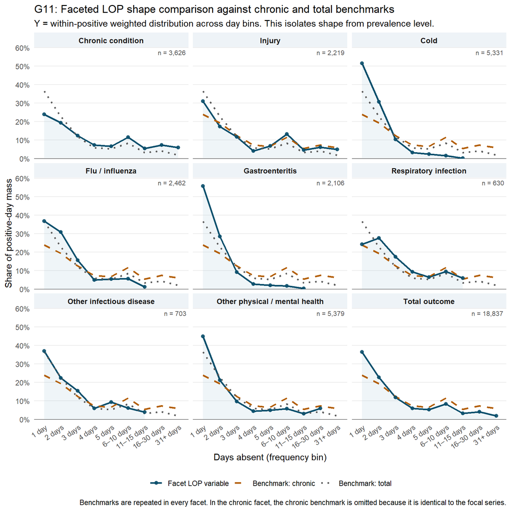

## G2 — Distribution of the Modeled Chronic-Illness Outcome

**Framing question**: What does the modeled outcome `days_absent_chronic` actually look like before any transformation or count-model assumption is imposed?

This section now has a two-part layout in both G2 and G21:

1. **Left, narrow panel**: one 100% stacked bar partitioning the full analytic sample into three mutually exclusive groups.
2. **Right, wide panel**: the exact chronic-day distribution among respondents who reported at least one chronic-absence day.

Definitions for the three left-panel subcomponents (these add to 63,843):

1. **No missed days**: `days_absent_total == 0`.
2. **≥1 chronic day**: `days_absent_chronic > 0` (includes people who may also report non-chronic days).
3. **Other-only missed day**: `days_absent_chronic == 0 & days_absent_total > 0`.

Keep the denominators straight:

1. In the left raw bar, the three segment counts add to the analytic sample size, 63,843.
2. In the left weighted bar, the three segment shares add to 100% of the employed-worker population frame.
3. In the right panel, only chronic reporters appear, so the bars describe the positive support of `days_absent_chronic` rather than the full sample.
4. The right panel intentionally follows the G01 logic from EDA-5: exact integer bars are colored by broader day-range bands so local spikes remain visible without losing tail structure.

### G2 — Raw Composite View

Sample partition plus chronic positive-day support on the raw count scale.

**Script preview: g2 data preparation from ds0**

```r
g2_partition <- ds0 %>%
  transmute(
    category = dplyr::case_when(
      days_absent_total == 0 ~ "No missed days",
      days_absent_chronic > 0 ~ ">=1 chronic day",
      days_absent_chronic == 0 & days_absent_total > 0 ~ "Other-only missed day",
      TRUE ~ NA_character_
    ),
    weight_value = .data[[weight_col]],
    days_absent_chronic = as.integer(days_absent_chronic)
  ) %>%
  filter(!is.na(category))

g2_partition_summary <- g2_partition %>%
  group_by(category) %>%
  summarise(
    n_raw = dplyr::n(),
    wt_sum = sum(weight_value, na.rm = TRUE),
    .groups = "drop"
  ) %>%
  mutate(
    pct_raw = n_raw / sum(n_raw) * 100,
    pct_weighted = wt_sum / sum(wt_sum) * 100,
    category = factor(
      category,
      levels = c("No missed days", ">=1 chronic day", "Other-only missed day")
    )
  )

g2_chronic_positive_distribution <- g2_partition %>%
  filter(days_absent_chronic > 0) %>%
  mutate(
    # Keep day_range for color mapping on numeric day bars
    day_range = dplyr::case_when(
      days_absent_chronic == 1  ~ "1 day",
      days_absent_chronic == 2  ~ "2 days",
      days_absent_chronic == 3  ~ "3 days",
      days_absent_chronic == 4  ~ "4 days",
      days_absent_chronic == 5  ~ "5 days",
      days_absent_chronic <= 10 ~ "6\u201310 days",
      days_absent_chronic <= 15 ~ "11\u201315 days",
      days_absent_chronic <= 30 ~ "16\u201330 days",
      TRUE ~ "31+ days"
    ),
    day_range = factor(day_range, levels = bin_levels)
  )

g2_partition_colors <- c(
  "No missed days" = "#D9D9D9",
  ">=1 chronic day" = "#D08C60",
  "Other-only missed day" = "#0B4F6C"
)

# Aggregate by exact numeric day for the right-panel distributions
g2_chronic_binned_distribution <- g2_chronic_positive_distribution %>%
  group_by(days_absent_chronic, day_range) %>%
  summarise(
    n_raw = dplyr::n(),
    wt_sum = sum(weight_value, na.rm = TRUE),
    .groups = "drop"
  ) %>%
  # Ensure every observed day is shown on the x-axis (step = 1).
  tidyr::complete(
    days_absent_chronic = seq(
      0,
      max(g2_chronic_positive_distribution$days_absent_chronic, na.rm = TRUE),
      by = 1
    ),
    fill = list(n_raw = 0, wt_sum = 0)
  ) %>%
  mutate(
    day_range = dplyr::case_when(
      days_absent_chronic == 0  ~ NA_character_,
      days_absent_chronic == 1  ~ "1 day",
      days_absent_chronic == 2  ~ "2 days",
      days_absent_chronic == 3  ~ "3 days",
      days_absent_chronic == 4  ~ "4 days",
      days_absent_chronic == 5  ~ "5 days",
      days_absent_chronic <= 10 ~ "6\u201310 days",
      days_absent_chronic <= 15 ~ "11\u201315 days",
      days_absent_chronic <= 30 ~ "16\u201330 days",
      TRUE ~ "31+ days"
    ),
    day_range = factor(day_range, levels = bin_levels),
    pct_raw_among_sample = n_raw / nrow(ds0) * 100,
    pct_weighted_among_sample = wt_sum / sum(ds0[[weight_col]], na.rm = TRUE) * 100,
    pct_weighted_among_reporters = wt_sum / sum(wt_sum, na.rm = TRUE) * 100
  )

g2_x_min <- 0
g2_x_max <- max(31, max(g2_chronic_binned_distribution$days_absent_chronic, na.rm = TRUE))
g2_x_major_breaks <- sort(unique(c(
  0,
  if (g2_x_min <= 1 && g2_x_max >= 1) 1 else numeric(0),
  seq(5 * ceiling(g2_x_min / 5), 5 * floor(g2_x_max / 5), by = 5)
)))
g2_x_major_breaks <- sort(unique(c(g2_x_major_breaks, g2_x_max)))
g2_x_minor_breaks <- seq(g2_x_min, g2_x_max, by = 1)
g2_x_ten_guides <- seq(10 * ceiling(g2_x_min / 10), 10 * floor(g2_x_max / 10), by = 10)

g2_day_range_colours <- c(
  "1 day" = "#f7941d",
  "2 days" = "#e8601c",
  "3 days" = "#cc3311",
  "4 days" = "#aa1133",
  "5 days" = "#880044",
  "6\u201310 days" = "#6a0177",
  "11\u201315 days" = "#49006a",
  "16\u201330 days" = "#2d004b",
  "31+ days" = "#0d0014"
)

compose_two_panel_grob <- function(left_plot, right_plot, left_width = 0.23, right_width = 0.77) {
  left_grob <- ggplot2::ggplotGrob(left_plot)
  right_grob <- ggplot2::ggplotGrob(right_plot)

  grid::grid.grabExpr({
    grid::grid.newpage()
    grid::pushViewport(
      grid::viewport(
        layout = grid::grid.layout(
          nrow = 1,
          ncol = 2,
          widths = grid::unit(c(left_width, right_width), "npc")
        )
      )
    )
    grid::pushViewport(grid::viewport(layout.pos.row = 1, layout.pos.col = 1))
    grid::grid.draw(left_grob)
    grid::upViewport()
    grid::pushViewport(grid::viewport(layout.pos.row = 1, layout.pos.col = 2))
    grid::grid.draw(right_grob)
    grid::upViewport(2)
  }, wrap.grobs = TRUE)
}
```

**Script preview: g2 graph construction**

```r
g2_left_raw_bar <- g2_partition_summary %>%
  ggplot(aes(x = "Analytic sample", y = pct_raw, fill = category)) +
  geom_col(width = 0.45, colour = "white", linewidth = 0.3) +
  geom_text(
    aes(
      label = paste0(scales::comma(n_raw), "\n", sprintf("%.1f%%", pct_raw))
    ),
    position = position_stack(vjust = 0.5),
    size = 3,
    lineheight = 0.95
  ) +
  scale_fill_manual(values = g2_partition_colors, guide = "none") +
  scale_y_continuous(
    labels = scales::label_percent(scale = 1),
    limits = c(0, 100),
    expand = expansion(mult = c(0, 0))
  ) +
  labs(
    x = NULL,
    y = "Share of sample"
  ) +
  theme_minimal(base_size = 11) +
  theme(
    axis.text.x = element_blank(),
    panel.grid.major.x = element_blank(),
    panel.grid.minor = element_blank(),
    plot.margin = margin(5.5, 0, 5.5, 5.5)
  )

g2_right_raw_distribution <- g2_chronic_binned_distribution %>%
  ggplot(aes(x = days_absent_chronic, y = n_raw, fill = day_range)) +
  geom_vline(
    xintercept = g2_x_ten_guides,
    colour = "#D9D9D9",
    linewidth = 0.35
  ) +
  geom_col(width = 0.9, alpha = 0.90) +
  geom_col(
    data = ~ dplyr::filter(.x, days_absent_chronic == 1),
    width = 0.9, colour = "black", fill = NA, alpha = 0.5
  ) +
  scale_x_continuous(
    breaks = g2_x_major_breaks,
    minor_breaks = g2_x_minor_breaks,
    limits = c(g2_x_min, g2_x_max + 1),
    expand = expansion(mult = c(0.01, 0.02))
  ) +
  scale_y_continuous(
    labels = scales::label_comma(),
    expand = expansion(mult = c(0, 0.05))
  ) +
  scale_fill_manual(values = g2_day_range_colours, name = "Day range") +
  labs(
    x = "Chronic-absence days (numeric)",
    y = "Respondent count"
  ) +
  theme_minimal(base_size = 11) +
  theme(
    panel.grid.major.x = element_blank(),
    panel.grid.minor.x = element_line(colour = "#ECECEC", linewidth = 0.20),
    panel.grid.minor.y = element_blank(),
    axis.text.x = element_text(size = 8),
    legend.position = c(0.985, 0.985),
    legend.justification = c(1, 1),
    legend.background = element_rect(fill = "#FFFFFFDD", colour = "#D0D0D0"),
    legend.key.size = grid::unit(0.28, "cm"),
    legend.title = element_text(size = 7),
    legend.text = element_text(size = 6),
    plot.margin = margin(5.5, 5.5, 5.5, 6)
  ) +
  guides(fill = guide_legend(ncol = 1, byrow = TRUE))

g2_positive_n <- sum(g2_chronic_binned_distribution$n_raw, na.rm = TRUE)

g2_right_raw_distribution <- g2_right_raw_distribution +
  labs(
    title = "G2: Positive chronic-day distribution",
    subtitle = paste0("n = ", scales::comma(g2_positive_n), " chronic reporters")
  )

g2_chronic_raw_distribution <- compose_two_panel_grob(
  g2_left_raw_bar,
  g2_right_raw_distribution,
  left_width = 0.22,
  right_width = 0.78
)

ggsave(
  paste0(prints_folder, "g2_chronic_raw_distribution.png"),
  g2_chronic_raw_distribution, width = 8.5, height = 5.5, dpi = 300
)

grid::grid.newpage()
grid::grid.draw(g2_chronic_raw_distribution)
```

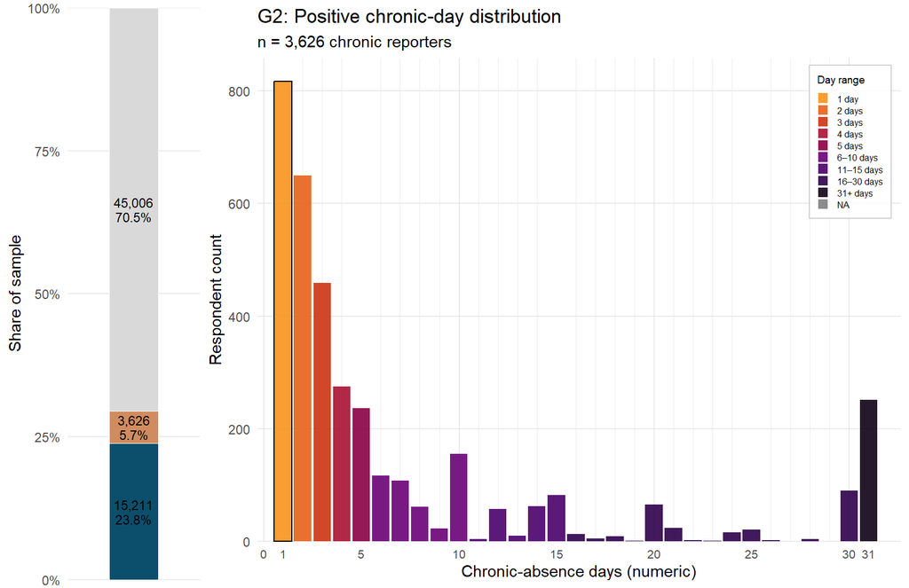

G2: Composite raw view of the modeled chronic-absence outcome. Left: a single 100% stacked bar partitions the 63,843 analytic respondents into three groups: no missed days of any kind, at least one chronic-illness day, and other-only missed days with zero chronic days. Right: among chronic reporters only, bars show the exact integer questionnaire values for days_absent_chronic, using the same day-range color logic as G01 in EDA-5. This separates the overall sample partition from the detailed positive chronic tail that later shape checks will evaluate.

### G21 — Weighted Composite View

Weighted analogue of G2 for population-representative prevalence interpretation.

**Script preview: g21 uses g2 prepared distributions**

```r
g2_partition <- ds0 %>%
  transmute(
    category = dplyr::case_when(
      days_absent_total == 0 ~ "No missed days",
      days_absent_chronic > 0 ~ ">=1 chronic day",
      days_absent_chronic == 0 & days_absent_total > 0 ~ "Other-only missed day",
      TRUE ~ NA_character_
    ),
    weight_value = .data[[weight_col]],
    days_absent_chronic = as.integer(days_absent_chronic)
  ) %>%
  filter(!is.na(category))

g2_partition_summary <- g2_partition %>%
  group_by(category) %>%
  summarise(
    n_raw = dplyr::n(),
    wt_sum = sum(weight_value, na.rm = TRUE),
    .groups = "drop"
  ) %>%
  mutate(
    pct_raw = n_raw / sum(n_raw) * 100,
    pct_weighted = wt_sum / sum(wt_sum) * 100,
    category = factor(
      category,
      levels = c("No missed days", ">=1 chronic day", "Other-only missed day")
    )
  )

g2_chronic_positive_distribution <- g2_partition %>%
  filter(days_absent_chronic > 0) %>%
  mutate(
    # Keep day_range for color mapping on numeric day bars
    day_range = dplyr::case_when(
      days_absent_chronic == 1  ~ "1 day",
      days_absent_chronic == 2  ~ "2 days",
      days_absent_chronic == 3  ~ "3 days",
      days_absent_chronic == 4  ~ "4 days",
      days_absent_chronic == 5  ~ "5 days",
      days_absent_chronic <= 10 ~ "6\u201310 days",
      days_absent_chronic <= 15 ~ "11\u201315 days",
      days_absent_chronic <= 30 ~ "16\u201330 days",
      TRUE ~ "31+ days"
    ),
    day_range = factor(day_range, levels = bin_levels)
  )

g2_partition_colors <- c(
  "No missed days" = "#D9D9D9",
  ">=1 chronic day" = "#D08C60",
  "Other-only missed day" = "#0B4F6C"
)

# Aggregate by exact numeric day for the right-panel distributions
g2_chronic_binned_distribution <- g2_chronic_positive_distribution %>%
  group_by(days_absent_chronic, day_range) %>%
  summarise(
    n_raw = dplyr::n(),
    wt_sum = sum(weight_value, na.rm = TRUE),
    .groups = "drop"
  ) %>%
  # Ensure every observed day is shown on the x-axis (step = 1).
  tidyr::complete(
    days_absent_chronic = seq(
      0,
      max(g2_chronic_positive_distribution$days_absent_chronic, na.rm = TRUE),
      by = 1
    ),
    fill = list(n_raw = 0, wt_sum = 0)
  ) %>%
  mutate(
    day_range = dplyr::case_when(
      days_absent_chronic == 0  ~ NA_character_,
      days_absent_chronic == 1  ~ "1 day",
      days_absent_chronic == 2  ~ "2 days",
      days_absent_chronic == 3  ~ "3 days",
      days_absent_chronic == 4  ~ "4 days",
      days_absent_chronic == 5  ~ "5 days",
      days_absent_chronic <= 10 ~ "6\u201310 days",
      days_absent_chronic <= 15 ~ "11\u201315 days",
      days_absent_chronic <= 30 ~ "16\u201330 days",
      TRUE ~ "31+ days"
    ),
    day_range = factor(day_range, levels = bin_levels),
    pct_raw_among_sample = n_raw / nrow(ds0) * 100,
    pct_weighted_among_sample = wt_sum / sum(ds0[[weight_col]], na.rm = TRUE) * 100,
    pct_weighted_among_reporters = wt_sum / sum(wt_sum, na.rm = TRUE) * 100
  )

g2_x_min <- 0
g2_x_max <- max(31, max(g2_chronic_binned_distribution$days_absent_chronic, na.rm = TRUE))
g2_x_major_breaks <- sort(unique(c(
  0,
  if (g2_x_min <= 1 && g2_x_max >= 1) 1 else numeric(0),
  seq(5 * ceiling(g2_x_min / 5), 5 * floor(g2_x_max / 5), by = 5)
)))
g2_x_major_breaks <- sort(unique(c(g2_x_major_breaks, g2_x_max)))
g2_x_minor_breaks <- seq(g2_x_min, g2_x_max, by = 1)
g2_x_ten_guides <- seq(10 * ceiling(g2_x_min / 10), 10 * floor(g2_x_max / 10), by = 10)

g2_day_range_colours <- c(
  "1 day" = "#f7941d",
  "2 days" = "#e8601c",
  "3 days" = "#cc3311",
  "4 days" = "#aa1133",
  "5 days" = "#880044",
  "6\u201310 days" = "#6a0177",
  "11\u201315 days" = "#49006a",
  "16\u201330 days" = "#2d004b",
  "31+ days" = "#0d0014"
)

compose_two_panel_grob <- function(left_plot, right_plot, left_width = 0.23, right_width = 0.77) {
  left_grob <- ggplot2::ggplotGrob(left_plot)
  right_grob <- ggplot2::ggplotGrob(right_plot)

  grid::grid.grabExpr({
    grid::grid.newpage()
    grid::pushViewport(
      grid::viewport(
        layout = grid::grid.layout(
          nrow = 1,
          ncol = 2,
          widths = grid::unit(c(left_width, right_width), "npc")
        )
      )
    )
    grid::pushViewport(grid::viewport(layout.pos.row = 1, layout.pos.col = 1))
    grid::grid.draw(left_grob)
    grid::upViewport()
    grid::pushViewport(grid::viewport(layout.pos.row = 1, layout.pos.col = 2))
    grid::grid.draw(right_grob)
    grid::upViewport(2)
  }, wrap.grobs = TRUE)
}
```

**Script preview: g21 graph construction**

```r
g21_left_weighted_bar <- g2_partition_summary %>%
  ggplot(aes(x = "Weighted population", y = pct_weighted, fill = category)) +
  geom_col(width = 0.45, colour = "white", linewidth = 0.3) +
  geom_text(
    aes(
      label = paste0(sprintf("%.1f%%", pct_weighted))
    ),
    position = position_stack(vjust = 0.5),
    size = 3,
    lineheight = 0.95
  ) +
  scale_fill_manual(values = g2_partition_colors, guide = "none") +
  scale_y_continuous(
    labels = scales::label_percent(scale = 1),
    limits = c(0, 100),
    expand = expansion(mult = c(0, 0))
  ) +
  labs(
    x = NULL,
    y = "Weighted % of workers"
  ) +
  theme_minimal(base_size = 11) +
  theme(
    axis.text.x = element_blank(),
    panel.grid.major.x = element_blank(),
    panel.grid.minor = element_blank(),
    plot.margin = margin(5.5, 0, 5.5, 5.5)
  )

g21_right_weighted_distribution <- g2_chronic_binned_distribution %>%
  ggplot(aes(x = days_absent_chronic, y = pct_weighted_among_reporters, fill = day_range)) +
  geom_vline(
    xintercept = g2_x_ten_guides,
    colour = "#D9D9D9",
    linewidth = 0.35
  ) +
  geom_col(width = 0.9, alpha = 0.90) +
  geom_col(
    data = ~ dplyr::filter(.x, days_absent_chronic == 1),
    width = 0.9, colour = "black", fill = NA, alpha = 0.5
  ) +
  scale_x_continuous(
    breaks = g2_x_major_breaks,
    minor_breaks = g2_x_minor_breaks,
    limits = c(g2_x_min, g2_x_max + 1),
    expand = expansion(mult = c(0.01, 0.02))
  ) +
  scale_y_continuous(
    labels = scales::label_percent(scale = 1),
    expand = expansion(mult = c(0, 0.05))
  ) +
  scale_fill_manual(values = g2_day_range_colours, name = "Day range") +
  labs(
    x = "Chronic-absence days (numeric)",
    y = "Weighted % among chronic reporters"
  ) +
  theme_minimal(base_size = 11) +
  theme(
    panel.grid.major.x = element_blank(),
    panel.grid.minor.x = element_line(colour = "#ECECEC", linewidth = 0.20),
    panel.grid.minor.y = element_blank(),
    axis.text.x = element_text(size = 8),
    legend.position = c(0.985, 0.985),
    legend.justification = c(1, 1),
    legend.background = element_rect(fill = "#FFFFFFDD", colour = "#D0D0D0"),
    legend.key.size = grid::unit(0.28, "cm"),
    legend.title = element_text(size = 7),
    legend.text = element_text(size = 6),
    plot.margin = margin(5.5, 5.5, 5.5, 6)
  ) +
  guides(fill = guide_legend(ncol = 1, byrow = TRUE))

g21_right_weighted_distribution <- g21_right_weighted_distribution +
  labs(
    title = "G21: Weighted positive chronic-day distribution",
    subtitle = "Bars sum to 100% across chronic reporters"
  )

g21_chronic_weighted_distribution <- compose_two_panel_grob(
  g21_left_weighted_bar,
  g21_right_weighted_distribution,
  left_width = 0.22,
  right_width = 0.78
)

ggsave(
  paste0(prints_folder, "g21_chronic_weighted_distribution.png"),
  g21_chronic_weighted_distribution, width = 8.5, height = 5.5, dpi = 300
)

grid::grid.newpage()
grid::grid.draw(g21_chronic_weighted_distribution)
```

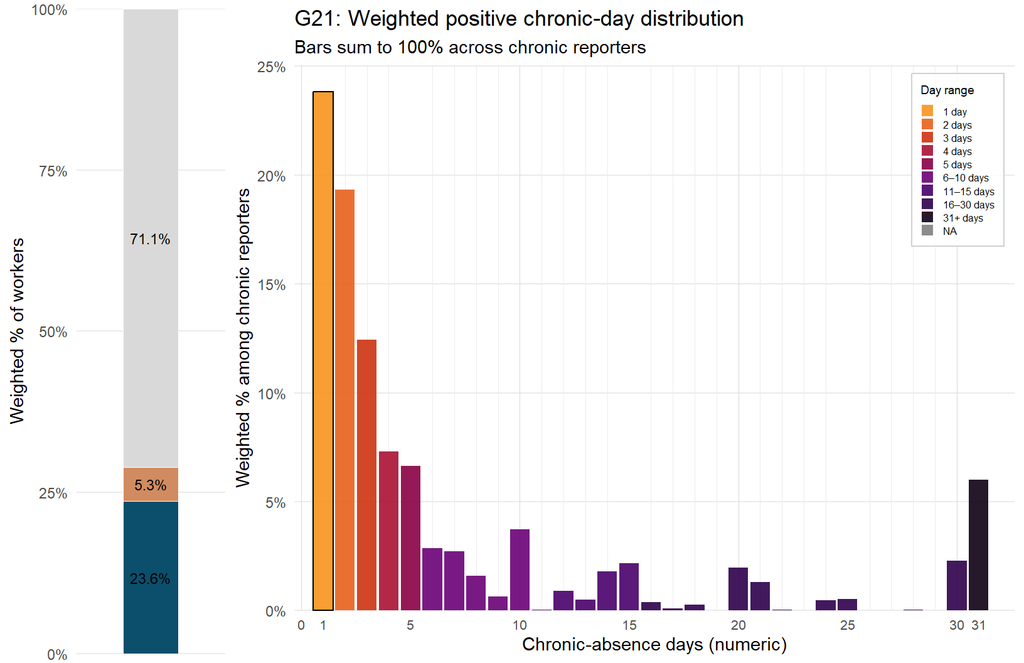

G21: Composite weighted view of the same chronic-absence outcome. Left: the full employed-worker population is partitioned into the same three mutually exclusive groups, now using pooled survey weights so the bar sums to 100%. Right: among chronic reporters only, each exact positive chronic-day value is shown as a weighted share of that chronic-reporter subpopulation, again using the G01 day-range color logic. This makes the positive-tail shape readable after the overall prevalence split has already been shown on the left.

### G22 — Chronic Cohort Split View

Top and bottom right panels compare chronic and non-chronic days within chronic reporters.

**Script preview: g22 data preparation from ds0**

```r
# g22 splits the right panel into two: top shows chronic-day distribution (same as g2 right),
# bottom shows distribution of days_absent_other for the same chronic-reporter cohort.

# Create days_absent_other variable: total days minus chronic days
g22_other_analysis <- ds0 %>%
  transmute(
    category = dplyr::case_when(
      days_absent_total == 0 ~ "No missed days",
      days_absent_chronic > 0 ~ ">=1 chronic day",
      days_absent_chronic == 0 & days_absent_total > 0 ~ "Other-only missed day",
      TRUE ~ NA_character_
    ),
    weight_value = .data[[weight_col]],
    days_absent_chronic = as.integer(days_absent_chronic),
    days_absent_total = as.integer(days_absent_total),
    days_absent_other = as.integer(days_absent_total - days_absent_chronic)
  ) %>%
  filter(!is.na(category) & days_absent_chronic > 0)

# Get the other-reason positive distribution with day-range mapping
g22_other_positive_distribution <- g22_other_analysis %>%
  mutate(
    day_range = dplyr::case_when(
      days_absent_other == 0  ~ "0 days",
      days_absent_other == 1  ~ "1 day",
      days_absent_other == 2  ~ "2 days",
      days_absent_other == 3  ~ "3 days",
      days_absent_other == 4  ~ "4 days",
      days_absent_other == 5  ~ "5 days",
      days_absent_other <= 10 ~ "6–10 days",
      days_absent_other <= 15 ~ "11–15 days",
      days_absent_other <= 30 ~ "16–30 days",
      TRUE ~ "31+ days"
    ),
    day_range = factor(day_range, levels = c("0 days", bin_levels))
  )

# Aggregate by exact numeric day for other-reason distribution
g22_other_binned_distribution <- g22_other_positive_distribution %>%
  group_by(days_absent_other, day_range) %>%
  summarise(
    n_raw = dplyr::n(),
    wt_sum = sum(weight_value, na.rm = TRUE),
    .groups = "drop"
  ) %>%
  # Ensure every observed day is shown (step = 1)
  tidyr::complete(
    days_absent_other = seq(
      0,
      max(g22_other_positive_distribution$days_absent_other, na.rm = TRUE),
      by = 1
    ),
    fill = list(n_raw = 0, wt_sum = 0)
  ) %>%
  mutate(
    day_range = dplyr::case_when(
      days_absent_other == 0  ~ "0 days",
      days_absent_other == 1  ~ "1 day",
      days_absent_other == 2  ~ "2 days",
      days_absent_other == 3  ~ "3 days",
      days_absent_other == 4  ~ "4 days",
      days_absent_other == 5  ~ "5 days",
      days_absent_other <= 10 ~ "6–10 days",
      days_absent_other <= 15 ~ "11–15 days",
      days_absent_other <= 30 ~ "16–30 days",
      TRUE ~ "31+ days"
    ),
    day_range = factor(day_range, levels = c("0 days", bin_levels))
  )

g22_other_x_min <- 0
g22_other_x_max <- max(g22_other_binned_distribution$days_absent_other, na.rm = TRUE)
g22_other_x_major_breaks <- sort(unique(c(
  g22_other_x_min,
  if (g22_other_x_min <= 1 && g22_other_x_max >= 1) 1 else numeric(0),
  seq(5 * ceiling(g22_other_x_min / 5), 5 * floor(g22_other_x_max / 5), by = 5)
)))
g22_other_x_major_breaks <- sort(unique(c(g22_other_x_major_breaks, g22_other_x_max)))
g22_other_x_minor_breaks <- seq(g22_other_x_min, g22_other_x_max, by = 1)
g22_other_x_ten_guides <- seq(10 * ceiling(g22_other_x_min / 10), 10 * floor(g22_other_x_max / 10), by = 10)
g22_top_y_max <- max(g2_chronic_binned_distribution$n_raw, na.rm = TRUE)
g22_top_y_limits <- c(0, g22_top_y_max * 1.08)
g22_top_y_breaks <- seq(0, 800, by = 100)

g22_bottom_plot_data <- g22_other_binned_distribution %>%
  dplyr::filter(days_absent_other >= 0)
g22_bottom_y_max <- max(g22_bottom_plot_data$n_raw, na.rm = TRUE)
g22_bottom_y_limits <- c(0, g22_bottom_y_max * 1.08)
g22_bottom_y_breaks <- pretty(g22_bottom_y_limits, n = 6)

g22_other_day_range_colours <- c("0 days" = "#B8B8B8", g2_day_range_colours)
```

**Script preview: g22 graph construction**

```r
# Compose three-panel layout: left chronic partition spans both rows, right split vertically

g22_chronic_raw_split_distribution <- compose_three_panel_grob(
  g2_left_raw_bar,
  g22_top_right_raw_distribution,
  g22_bottom_right_other_distribution,
  left_width = 0.22,
  right_width = 0.78
)

# Display for Quarto figure capture
grid::grid.draw(g22_chronic_raw_split_distribution)

# Save high-res version to prints folder
ggsave(
  paste0(prints_folder, "g22_chronic_vs_other_raw_split_distribution.png"),
  g22_chronic_raw_split_distribution, width = 8.5, height = 7, dpi = 300
)
```

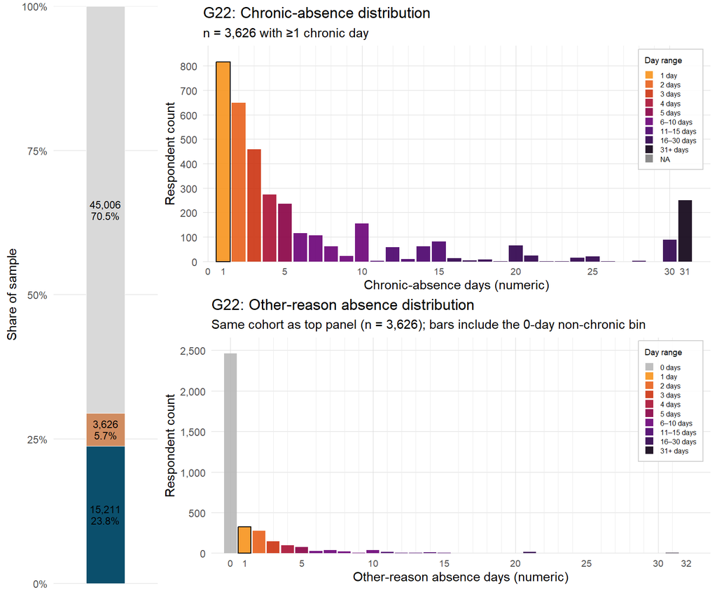

G22: Composite raw split view extending G2. Left: the same 100% stacked partition of all 63,843 analytic respondents into no missed days, ≥1 chronic day, and other-only missed days. Right-top: exact chronic-day distribution for chronic reporters (n = 3,626), preserving the G01 day-range color logic. Right-bottom: for that same chronic-reporter cohort (n = 3,626), the distribution of non-chronic missed days, computed as days_absent_total minus days_absent_chronic. This separates cohort composition (left) from within-cohort chronic vs non-chronic day-count structure (right).

### G23 — Other-Only Cohort Split View

G22 variant where the lower-right panel switches to the other-only respondent group.

**Script preview: g23 data preparation from ds0**

```r
# g23 keeps g22 geometry but changes the lower-right panel to the "other-only" cohort:
# respondents with >=1 non-chronic day and 0 chronic days (n = 15,211).
g23_other_only_analysis <- ds0 %>%
  transmute(
    category = dplyr::case_when(
      days_absent_total == 0 ~ "No missed days",
      days_absent_chronic > 0 ~ ">=1 chronic day",
      days_absent_chronic == 0 & days_absent_total > 0 ~ "Other-only missed day",
      TRUE ~ NA_character_
    ),
    weight_value = .data[[weight_col]],
    days_absent_chronic = as.integer(days_absent_chronic),
    days_absent_total = as.integer(days_absent_total),
    days_absent_other = as.integer(days_absent_total - days_absent_chronic)
  ) %>%
  filter(!is.na(category) & days_absent_chronic == 0 & days_absent_total > 0)

g23_other_only_binned_distribution <- g23_other_only_analysis %>%
  mutate(
    day_range = dplyr::case_when(
      days_absent_other == 1  ~ "1 day",
      days_absent_other == 2  ~ "2 days",
      days_absent_other == 3  ~ "3 days",
      days_absent_other == 4  ~ "4 days",
      days_absent_other == 5  ~ "5 days",
      days_absent_other <= 10 ~ "6–10 days",
      days_absent_other <= 15 ~ "11–15 days",
      days_absent_other <= 30 ~ "16–30 days",
      TRUE ~ "31+ days"
    ),
    day_range = factor(day_range, levels = bin_levels)
  ) %>%
  group_by(days_absent_other, day_range) %>%
  summarise(
    n_raw = dplyr::n(),
    wt_sum = sum(weight_value, na.rm = TRUE),
    .groups = "drop"
  ) %>%
  tidyr::complete(
    days_absent_other = seq(
      1,
      max(days_absent_other, na.rm = TRUE),
      by = 1
    ),
    fill = list(n_raw = 0, wt_sum = 0)
  ) %>%
  mutate(
    day_range = dplyr::case_when(
      days_absent_other == 1  ~ "1 day",
      days_absent_other == 2  ~ "2 days",
      days_absent_other == 3  ~ "3 days",
      days_absent_other == 4  ~ "4 days",
      days_absent_other == 5  ~ "5 days",
      days_absent_other <= 10 ~ "6–10 days",
      days_absent_other <= 15 ~ "11–15 days",
      days_absent_other <= 30 ~ "16–30 days",
      TRUE ~ "31+ days"
    ),
    day_range = factor(day_range, levels = bin_levels)
  )

g23_other_x_min <- 0
g23_other_x_max <- max(g23_other_only_binned_distribution$days_absent_other, na.rm = TRUE)
g23_other_x_major_breaks <- sort(unique(c(
  0,
  1,
  seq(5 * ceiling(g23_other_x_min / 5), 5 * floor(g23_other_x_max / 5), by = 5)
)))
g23_other_x_major_breaks <- sort(unique(c(g23_other_x_major_breaks, g23_other_x_max)))
g23_other_x_minor_breaks <- seq(g23_other_x_min, g23_other_x_max, by = 1)
g23_other_x_ten_guides <- seq(10 * ceiling(g23_other_x_min / 10), 10 * floor(g23_other_x_max / 10), by = 10)

g23_bottom_y_max <- max(g23_other_only_binned_distribution$n_raw, na.rm = TRUE)
g23_bottom_y_limits <- c(0, g23_bottom_y_max * 1.08)
g23_bottom_y_breaks <- pretty(g23_bottom_y_limits, n = 6)
```

**Script preview: g23 graph construction**

```r
g23_chronic_vs_other_only_split_distribution <- compose_three_panel_grob(
  g2_left_raw_bar,
  g22_top_right_raw_distribution,
  g23_bottom_right_other_only_distribution,
  left_width = 0.22,
  right_width = 0.78
)

grid::grid.draw(g23_chronic_vs_other_only_split_distribution)

ggsave(
  paste0(prints_folder, "g23_chronic_vs_other_only_raw_split_distribution.png"),
  g23_chronic_vs_other_only_split_distribution, width = 8.5, height = 7, dpi = 300
)



# =============================================================================
# G3 FAMILY — Modeled-Outcome Shape Checks for days_absent_chronic
# Purpose: Evaluate candidate transformations for two-part/hurdle modeling:
# (g31) Full distribution (y >= 0): compare transformations that handle zero,
#       informing zero-inflation / hurdle probability component
# (g32) Positive-part only (y > 0): assess normality of conditional distribution,
#       informing model specification for chronic reporters
# =============================================================================
```

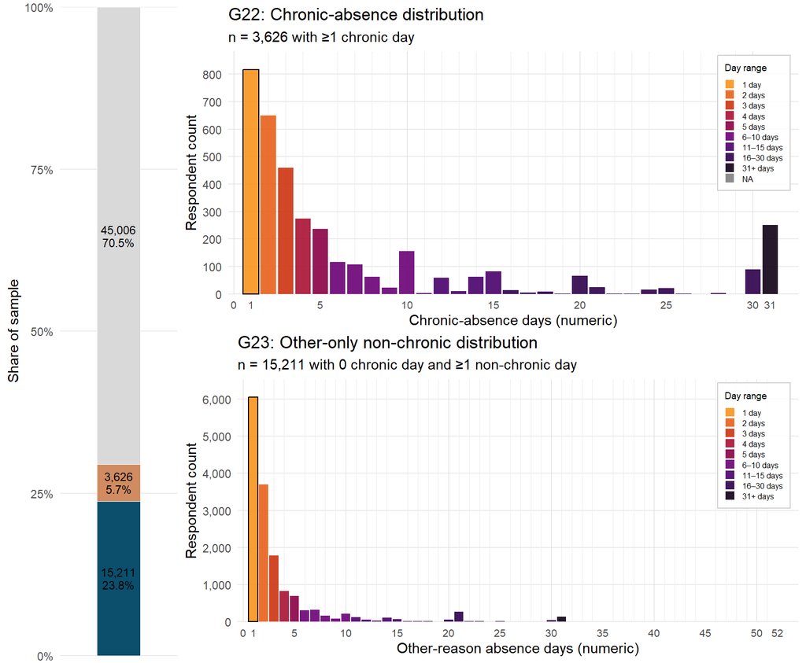

G23: Variant of G22 with the same left partition and same top-right chronic-day distribution. The lower-right panel now uses the remaining other-only cohort (n = 15,211): respondents with 0 chronic days and at least 1 non-chronic missed day. The x-axis starts at 0 for orientation, but no bar is plotted at 0, so the first visible bar is day 1.

## G3 Family — The shape of the Modeled Outcome

**Framing question**: How do the response values of `days_absent_*` distribute? By what shapes can we approximate their empirical distributions?

**Two-part modeling rationale**: The chronic-absence outcome has two inherent structures: - **Full distribution** (y ≥ 0): includes zero mass and positive-tail shape; informs zero-inflation / hurdle probability component - **Positive-part only** (y > 0): among chronic reporters; informs conditional count/duration component

This section builds diagnostic graphs for both perspectives.

Now that G2 has shown the raw and weighted empirical distribution of `days_absent_chronic`, we can ask the next question: which outcome scale best regularizes each component for diagnostics and moment-based summaries?

This section separates two linked issues:

1. G2 already showed the empirical **zero mass** directly on the raw outcome scale.
2. The checks below ask how the **positive tail** behaves under candidate transformations once that zero mass is acknowledged.

The table below states the modeling assumptions for each candidate scale. Then we compare empirical shape diagnostics and ECDF curves to see how strongly each transformation compresses upper-tail behavior for the chronic-absence outcome.

Modeled-outcome table: transformation assumptions for days_absent_chronic

| Candidate scale | Formula | Requires y > 0 | Handles zero directly | Primary assumption | Modeling implication |
| --- | --- | --- | --- | --- | --- |
| Raw count | y | No | Yes | Count process with potentially strong right-skew | Natural scale for Poisson / NB / hurdle count models |
| Square root | sqrt(y) | No | Yes | Variance stabilisation for moderate counts | Useful descriptive view when tail is less extreme |
| Log-shift | log1p(y) | No | Yes | Multiplicative effects become additive on transformed scale | Common for linear-model diagnostics on skewed outcomes |
| Inverse hyperbolic sine | asinh(y) | No | Yes | Log-like in upper tail while remaining defined at zero | Robust alternative when zeros are frequent |
| Positive-part log | log(y) for y > 0 | Yes | No | Conditional model after a separate zero process | Aligned with two-part / hurdle interpretation |

g31 table: shape diagnostics (full sample) for days_absent_chronic across candidate scales

| Scale | Zero mass | P90 | P99 | Skewness |
| --- | --- | --- | --- | --- |
| Raw count (y) | 94.32% | 0.00 | 14.00 | 9.13 |
| Square root: sqrt(y) | 94.32% | 0.00 | 3.74 | 6.00 |
| Log-shift: log1p(y) | 94.32% | 0.00 | 2.71 | 5.38 |
| IHS: asinh(y) | 94.32% | 0.00 | 3.33 | 5.17 |

### G31 — Full-Sample Transformation Diagnostics

Full-sample ECDF comparison including the structural zero mass.

**Script preview: g31 transformation data preparation**

```r
# Build long-form transformed variants of days_absent_chronic (full sample, y >= 0)
# to compare shape diagnostics side-by-side.
g31_transform_data <- ds0 %>%
  transmute(
    y_raw   = days_absent_chronic,
    y_sqrt  = sqrt(days_absent_chronic),
    y_log1p = log1p(days_absent_chronic),
    y_asinh = asinh(days_absent_chronic)
  ) %>%
  tidyr::pivot_longer(
    cols = everything(),
    names_to = "scale_id",
    values_to = "value"
  ) %>%
  mutate(
    scale_label = factor(
      dplyr::recode(
        scale_id,
        y_raw = "Raw count (y)",
        y_sqrt = "Square root: sqrt(y)",
        y_log1p = "Log-shift: log1p(y)",
        y_asinh = "IHS: asinh(y)"
      ),
      levels = c(
        "Raw count (y)",
        "Square root: sqrt(y)",
        "Log-shift: log1p(y)",
        "IHS: asinh(y)"
      )
    )
  )

skewness_estimate <- function(x) {
  x <- x[is.finite(x)]
  if (length(x) < 3) return(NA_real_)
  m <- mean(x)
  s <- stats::sd(x)
  if (!is.finite(s) || s == 0) return(0)
  mean((x - m)^3) / (s^3)
}

g31_shape_summary <- g31_transform_data %>%
  group_by(scale_label) %>%
  summarise(
    zero_mass_pct = mean(value == 0, na.rm = TRUE) * 100,
    p90           = stats::quantile(value, probs = 0.90, na.rm = TRUE, names = FALSE),
    p99           = stats::quantile(value, probs = 0.99, na.rm = TRUE, names = FALSE),
    skewness      = skewness_estimate(value),
    .groups = "drop"
  )

g31_shape_table <- g31_shape_summary %>%
  mutate(
    scale_label = as.character(scale_label),
    zero_mass_pct = sprintf("%.2f%%", zero_mass_pct),
    p90 = sprintf("%.2f", p90),
    p99 = sprintf("%.2f", p99),
    skewness = sprintf("%.2f", skewness)
  )

if (isTRUE(getOption("knitr.in.progress"))) {
  knitr::kable(
    g31_shape_table,
    format = "html",
    col.names = c("Scale", "Zero mass", "P90", "P99", "Skewness"),
    align = c("l", "r", "r", "r", "r"),
    caption = "g31 table: shape diagnostics (full sample) for days_absent_chronic across candidate scales"
  )
} else {
  print(g31_shape_table)
}
```

**Script preview: g31 graph construction**

```r
# g31: ECDF overlays (full sample, y >= 0) in faceted panels make skew reduction
# and tail compression easy to compare. Informs zero-inflation / hurdle probability.
g31_transform_ecdf <- g31_transform_data %>%
  ggplot(aes(x = value)) +
  stat_ecdf(linewidth = 0.9, colour = "#005072") +
  facet_wrap(~ scale_label, scales = "free_x", ncol = 2) +
  labs(
    title = "g31: Transformation diagnostics for days_absent_chronic (full sample, y ≥ 0)",
    subtitle = "Full analytic sample including zero chronic absences. Examines zero-inflation structure and tail behavior.",
    x = "Outcome value on candidate scale",
    y = "Empirical cumulative proportion",
    caption = "Full sample perspective: evaluates zero mass (94.3%) and skew among all respondents. Lower skew and compressed upper tail suggest easier Gaussian approximation in the zero-inflation component."
  ) +
  theme_minimal(base_size = 11) +
  theme(
    strip.text = element_text(face = "bold"),
    panel.grid.minor = element_blank()
  )

ggsave(
  paste0(prints_folder, "g31_transform_ecdf.png"),
  g31_transform_ecdf, width = 8.5, height = 5.5, dpi = 300
)
print(g31_transform_ecdf)
```

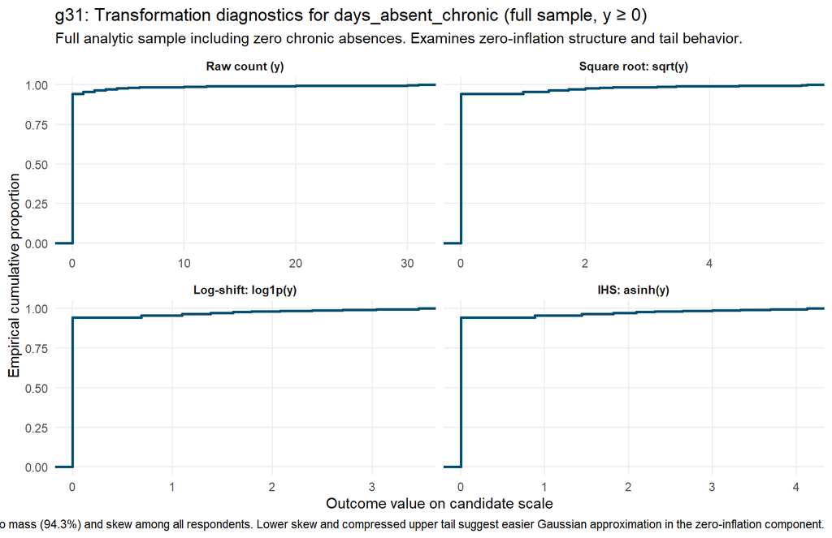

## g32 — Shape Diagnostics for Positive-Part Model

Among the 3,626 chronic reporters (5.7% of 63,843), the conditional distribution of `days_absent_chronic | y > 0` has its own shape signature. This is the outcome that drives the count-process parameters in a two-part / hurdle / zero-inflated model. The g32 graphs below focus on *only* the positive-part data and ask: which scale best compresses the conditional tail?

g32 table: shape diagnostics (positive-part only) for days_absent_chronic across candidate scales

| Scale | N (y > 0) | P90 | P99 | Skewness |
| --- | --- | --- | --- | --- |
| Raw count (y) | 3626 | 25.00 | 31.00 | 1.74 |
| Square root: sqrt(y) | 3626 | 5.00 | 5.57 | 1.20 |
| Log-shift: log1p(y) | 3626 | 3.26 | 3.47 | 0.73 |
| IHS: asinh(y) | 3626 | 3.91 | 4.13 | 0.58 |
| Log (positive-part): log(y) | 3626 | 3.22 | 3.43 | 0.47 |

**Script preview: g32 positive-part data preparation**

```r
# Build long-form transformed variants of days_absent_chronic (positive part only, y > 0)
# to assess Gaussian approximation among chronic reporters.
g32_transform_data <- ds0 %>%
  filter(days_absent_chronic > 0) %>%  # Focus on positive-part only
  transmute(
    y_raw   = days_absent_chronic,
    y_sqrt  = sqrt(days_absent_chronic),
    y_log1p = log1p(days_absent_chronic),
    y_asinh = asinh(days_absent_chronic),
    y_poslog = log(days_absent_chronic)  # Positive-part log (only valid for y > 0)
  ) %>%
  tidyr::pivot_longer(
    cols = everything(),
    names_to = "scale_id",
    values_to = "value"
  ) %>%
  mutate(
    scale_label = factor(
      dplyr::recode(
        scale_id,
        y_raw = "Raw count (y)",
        y_sqrt = "Square root: sqrt(y)",
        y_log1p = "Log-shift: log1p(y)",
        y_asinh = "IHS: asinh(y)",
        y_poslog = "Log (positive-part): log(y)"
      ),
      levels = c(
        "Raw count (y)",
        "Square root: sqrt(y)",
        "Log-shift: log1p(y)",
        "IHS: asinh(y)",
        "Log (positive-part): log(y)"
      )
    )
  )

g32_shape_summary <- g32_transform_data %>%
  group_by(scale_label) %>%
  summarise(
    n_obs     = n(),
    p90       = stats::quantile(value, probs = 0.90, na.rm = TRUE, names = FALSE),
    p99       = stats::quantile(value, probs = 0.99, na.rm = TRUE, names = FALSE),
    skewness  = skewness_estimate(value),
    .groups = "drop"
  )

g32_shape_table <- g32_shape_summary %>%
  mutate(
    scale_label = as.character(scale_label),
    n_obs = sprintf("%d", n_obs),
    p90 = sprintf("%.2f", p90),
    p99 = sprintf("%.2f", p99),
    skewness = sprintf("%.2f", skewness)
  )

if (isTRUE(getOption("knitr.in.progress"))) {
  knitr::kable(
    g32_shape_table,
    format = "html",
    col.names = c("Scale", "N (y > 0)", "P90", "P99", "Skewness"),
    align = c("l", "r", "r", "r", "r"),
    caption = "g32 table: shape diagnostics (positive-part only) for days_absent_chronic across candidate scales"
  )
} else {
  print(g32_shape_table)
}
```

**Script preview: g32 graph construction**

```r
# g32: ECDF overlays (positive part only, y > 0) in faceted panels.
# Three reference lines per facet:
#   Empirical  — orange solid (actual data)
#   Gaussian   — purple dashed (same mean/SD, continuous)
#   Poisson    — teal dotted (lambda = mean of raw positive part; x-grid transformed per scale)
# Informs model specification for the conditional distribution among chronic reporters.

# Gaussian reference parameters per scale
g32_gauss_params <- g32_transform_data %>%
  group_by(scale_label) %>%
  summarise(
    mu = mean(value, na.rm = TRUE),
    sigma = sd(value, na.rm = TRUE),
    min_val = min(value, na.rm = TRUE),
    max_val = max(value, na.rm = TRUE),
    .groups = "drop"
  )

# Gaussian ECDF reference curves
g32_gauss_ecdf <- g32_gauss_params %>%
  rowwise() %>%
  mutate(
    x_grid  = list(seq(min_val, max_val, length.out = 300)),
    cdf_grid = list(pnorm(x_grid, mean = mu, sd = sigma))
  ) %>%
  unnest(cols = c(x_grid, cdf_grid)) %>%
  ungroup() %>%
  mutate(series = "Gaussian")

# Poisson reference: lambda = mean of raw positive-part days_absent_chronic.
# For each scale, compute ppois() on the raw integer grid then apply the
# same transformation to the x values so the CDF is plotted on each panel's axis.
g32_lambda <- mean(ds0$days_absent_chronic[ds0$days_absent_chronic > 0], na.rm = TRUE)
g32_raw_x_max <- max(ds0$days_absent_chronic[ds0$days_absent_chronic > 0], na.rm = TRUE)

g32_pois_ecdf <- tibble::tibble(
  x_raw    = seq_len(g32_raw_x_max),
  cdf_grid = ppois(x_raw, lambda = g32_lambda)
) %>%
  tidyr::crossing(
    tibble::tibble(scale_label = levels(g32_transform_data$scale_label))
  ) %>%
  mutate(
    x_grid = dplyr::case_when(
      scale_label == "Raw count (y)"               ~ as.double(x_raw),
      scale_label == "Square root: sqrt(y)"        ~ sqrt(x_raw),
      scale_label == "Log-shift: log1p(y)"         ~ log1p(x_raw),
      scale_label == "IHS: asinh(y)"               ~ asinh(x_raw),
      scale_label == "Log (positive-part): log(y)" ~ log(x_raw)
    ),
    scale_label = factor(scale_label, levels = levels(g32_transform_data$scale_label)),
    series = "Poisson"
  ) %>%
  select(scale_label, x_grid, cdf_grid, series)

# Combine reference curves for a single geom_line call
g32_ref_curves <- bind_rows(
  g32_gauss_ecdf %>% select(scale_label, x_grid, cdf_grid, series),
  g32_pois_ecdf
)

# Colour and linetype mappings
g32_ref_colours   <- c("Empirical" = "#D55E00", "Gaussian" = "#7030A0", "Poisson" = "#009E73")
g32_ref_linetypes <- c("Empirical" = "solid",   "Gaussian" = "dashed",  "Poisson" = "dotted")
g32_ref_linewidths <- c("Empirical" = 0.9,       "Gaussian" = 0.5,       "Poisson" = 0.5)

# Create the g32 plot
g32_transform_ecdf <- g32_transform_data %>%
  ggplot(aes(x = value)) +
  # Empirical ECDF
  stat_ecdf(
    aes(colour = "Empirical", linetype = "Empirical"),
    linewidth = 0.9
  ) +
  # Gaussian + Poisson reference ECDFs
  geom_line(
    data = g32_ref_curves,
    aes(x = x_grid, y = cdf_grid, colour = series, linetype = series),
    linewidth = 0.5,
    alpha = 0.90
  ) +
  scale_colour_manual(values = g32_ref_colours,   name = NULL) +
  scale_linetype_manual(values = g32_ref_linetypes, name = NULL) +
  facet_wrap(~ scale_label, scales = "free_x", ncol = 2) +
  labs(
    title = "g32: Transformation diagnostics for days_absent_chronic (positive part, y > 0)",
    subtitle = paste0(
      "Chronic reporters only (n = 3,626). ",
      "Orange solid = empirical ECDF; purple dashed = Gaussian (same mean/SD); ",
      "teal dotted = Poisson (\u03bb = ", sprintf("%.2f", g32_lambda), "). ",
      "Closer overlap = better approximation."
    ),
    x = "Outcome value on candidate scale",
    y = "Empirical cumulative proportion",
    caption = paste0(
      "Poisson CDF uses lambda = mean of raw positive-part days; x-axis reflects the same transformation applied to each scale's panel. ",
      "Where empirical lies between Gaussian and Poisson, neither model is a perfect fit. ",
      "Where empirical tracks Gaussian most closely (log scale), a log-link or Gaussian model is most appropriate."
    )
  ) +
  theme_minimal(base_size = 11) +
  theme(
    strip.text = element_text(face = "bold"),
    panel.grid.minor = element_blank(),
    legend.position = "bottom"
  )

ggsave(
  paste0(prints_folder, "g32_transform_ecdf.png"),
  g32_transform_ecdf, width = 8.5, height = 5.5, dpi = 300
)
print(g32_transform_ecdf)
```

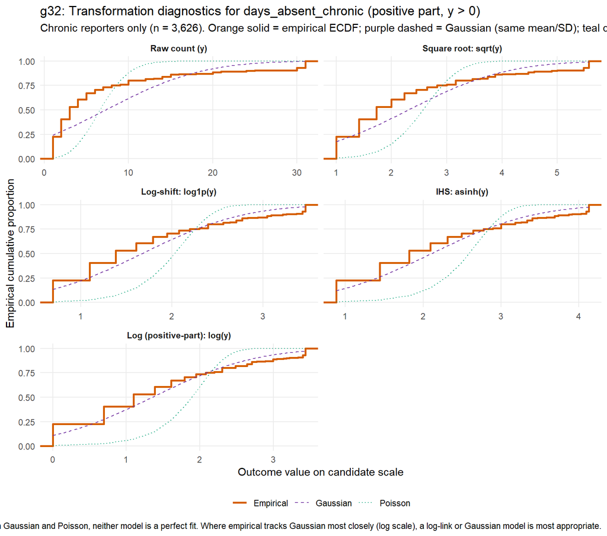

### Interpreting g32 — Reading the Transformation Signals

**What should you see in g32?** Each panel shows an empirical cumulative distribution function (ECDF) for one scale. The ECDF is a step function that rises from 0 (at the minimum value) to 1 (at the maximum), with the steepness indicating density. A **steep middle section** means many observations cluster in that value range. An **early/fast steep rise followed by a long gentle tail** signals strong right-skew. An **S-shaped curve** (slow rise, steep middle, slow rise again) approximates Gaussian shape.

**How to tell which transformation approximates normality better:**

**Visual takeaway from g32:**

- **Raw count (y)**: ECDF rises abruptly (many respondents with 1–3 days), then flattens into a long, gentle tail extending to 31+ days. **Verdict**: Heavy right-skew; low values clustered, high values sparse. This is **not** Gaussian.
- **Square root sqrt(y)**: Somewhat less abrupt rise, tail still visible but compressed vs. raw. **Intermediate improvement**.
- **Log-shift log1p(y)** and **IHS asinh(y)**: Both show compressed tails compared to sqrt. Very similar visual shape—both are effective tail-shrinkage transformations.
- **Log (positive-part) log(y)**: Cleanest ECDF shape in this group—steep central rise with the shortest, flattest tail. **Best Gaussian approximation** among the five candidates.

**The skewness column in the g32 table is the quantitative signal:**

| Scale | Skewness |
| --- | --- |
| Raw count | 1.74 |
| sqrt(y) | 1.20 |
| log1p(y) | 0.73 |
| IHS asinh(y) | 0.58 |
| **log(y)** | **0.47** |

Skewness measures asymmetry. A Gaussian has skewness = 0. **The lower the skewness, the closer to symmetric normal distribution.** The log(y) transformation achieves the lowest skewness (0.47), indicating it most successfully removes the right tail asymmetry.

### What the Reader Should Take Away

**Opinion about the chronic-absence outcome distribution:**

1. **The positive-part conditional distribution is markedly right-skewed in raw counts**, with most chronic reporters contributing 1–5 days and a long sparse tail up to 31+ days. Raw counts are suitable for count models (Poisson, negative binomial, hurdle), but not for linear models on the natural scale.
2. **Log transformation is the most effective remedy.** When days are log-transformed, the conditional distribution becomes substantially more symmetric, approaching Gaussian shape. This supports:
   - **Log-link models** (Poisson GLM with `log(days_absent_chronic)` as the expected value on the log scale)
   - **Linear models on log scale** (fit a linear regression to `log(days_absent_chronic | y > 0)`, then back-transform predictions)
3. **sqrt and log1p are adequate middle-ground options** if log is inconvenient (e.g., interpretability concerns). Both compress the tail noticeably, though not as effectively as log.
4. **The IHS (inverse hyperbolic sine) is comparable to log1p**, offering a symmetric alternative that remains defined at zero—useful for full-sample analysis or if you want a single transformation that works for both zero and positive values.

**Modeling implication**: For a two-part/hurdle model predicting chronic absence: - **Part 1 (zero-inflation)**: Use any sensible binary model (logistic) to predict presence/absence of any chronic days. - **Part 2 (positive-part)**: Fit a count model with log link OR a Gaussian linear model on `log(days)`. The log link choice is strongly supported by the g32 evidence that log-transformed positive days approximate normality.

This combination yields a model whose coefficients describe shifts in the **typical chronic-absence day count among reporters**, not distorted artifacts of raw-scale skew.

### Why Gaussian Approximation Matters for Moments

The ECDF above shows that transformations compress the tail — but *why* does that help us? The answer lies in how we interpret a distribution’s **moments** (mean and standard deviation):

- The **mean** is meant to represent the “typical” value — the center of mass. When a distribution is strongly right-skewed, the mean is pulled toward the tail and no longer represents a typical respondent. Instead it reflects a compromise between the bulk of zeros/low values and the rare extreme values.
- The **standard deviation** is meant to capture symmetric spread around the mean — “how far a typical observation falls from center.” Under skew, SD conflates two different phenomena: the tight cluster of low values *and* the sparse tail of high values. It loses its intuitive interpretation as a single “spread” measure.

A Gaussian (normal) distribution is the **reference case** where moments are maximally informative: the mean *is* the mode *is* the median, and ±1 SD captures exactly 68% of observations symmetrically. The closer our transformed outcome approximates this shape, the more trustworthy and interpretable its summary statistics become for modeling:

- Regression coefficients (which estimate shifts in the conditional mean) describe shifts in the *typical* outcome, not shifts distorted by tail behavior.
- Confidence intervals and prediction intervals based on ±SE have correct coverage.
- Effect size comparisons (Cohen’s *d*, standardized betas) carry their intended meaning.

## g33 — Gaussian Fit: Conditional Distribution Assessment

The graph below overlays the empirical density (orange) against a Gaussian with the *same* mean and SD (blue dashed) for each candidate scale, using only the positive-part data. Where the two curves diverge, the moments are “lying” — summarizing a shape they don’t actually describe. Where they overlap, the moments are trustworthy descriptors for the conditional chronic-absence outcome among reporters.

**Script preview: g33 Gaussian reference data preparation**

```r
# Density vs fitted Gaussian overlay per transformation scale.
# Shows how well each scale's empirical distribution matches a normal with the
# same mean and SD — the better the match, the more its mean captures "typical"
# and its SD captures "spread" in the intuitive, symmetric sense.
# Computed for positive-part only (y > 0).

g33_gauss_ref <- g32_transform_data %>%
  group_by(scale_label) %>%
  summarise(
    mu = mean(value, na.rm = TRUE),
    sigma = sd(value, na.rm = TRUE),
    .groups = "drop"
  )

g33_gauss_curve <- g33_gauss_ref %>%
  rowwise() %>%
  mutate(
    x_grid = list(seq(mu - 4 * sigma, mu + 4 * sigma, length.out = 300)),
    y_grid = list(dnorm(x_grid, mean = mu, sd = sigma))
  ) %>%
  unnest(cols = c(x_grid, y_grid)) %>%
  ungroup()
```

**Script preview: g33 graph construction**

```r
g33_density_vs_gaussian <- g32_transform_data %>%
  ggplot(aes(x = value)) +
  geom_density(
    aes(colour = "Empirical density"),
    linewidth = 0.9, key_glyph = "path"
  ) +
  geom_line(
    data = g33_gauss_curve,
    aes(x = x_grid, y = y_grid, colour = "Gaussian (same mean & SD)"),
    linewidth = 0.7, linetype = "dashed", key_glyph = "path"
  ) +
  facet_wrap(~ scale_label, scales = "free", ncol = 2) +
  scale_colour_manual(
    values = c("Empirical density" = "#D55E00", "Gaussian (same mean & SD)" = "#005072"),
    name = NULL
  ) +
  labs(
    title = "g33: Why reduced skew matters for positive-part modeling (y > 0)",
    subtitle = paste0(
      "Chronic reporters only. When orange curve matches blue dashed curve, the mean and SD\n",
      "fully characterize the conditional distribution -- each transformation's behavior is predictable."
    ),
    x = "Outcome value on candidate scale",
    y = "Density",
    caption = paste0(
      "Blue dashed = N(mean, SD) fitted to positive-part data.\n ",
      "Better overlap = mean/SD statistics are trustworthy for conditional modeling. Informs choice of log-link or power transformation."
    )
  ) +
  theme_minimal(base_size = 11) +
  theme(
    strip.text = element_text(face = "bold"),
    legend.position = "bottom",
    panel.grid.minor = element_blank()
  )

ggsave(
  paste0(prints_folder, "g33_density_vs_gaussian.png"),
  g33_density_vs_gaussian, width = 8.5, height = 5.5, dpi = 300
)
print(g33_density_vs_gaussian)


# =============================================================================
# G3 FAMILY — Composite Outcome Distribution    [STUB]
# Framing question: How does days_absent_total distribute — its zero mass,
#   right-tail shape, and key quantiles?
# g3: annotated histogram with zero-inflation and quantile markers
# =============================================================================
```

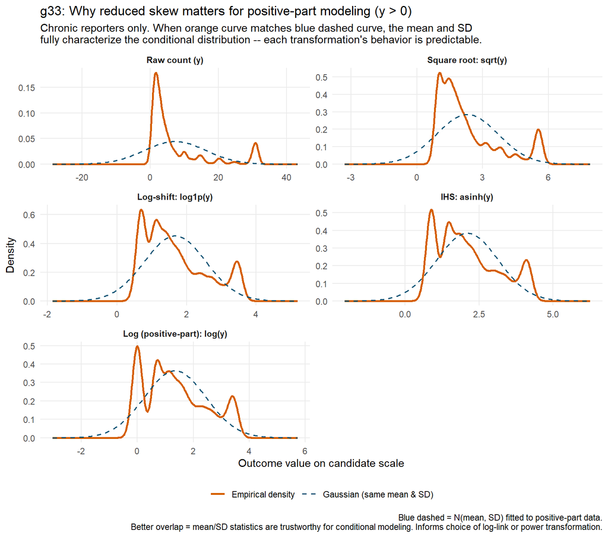

### Why Zero-Inflated Negative Binomial (ZINB)?

The G2 chronic-outcome distributions and the shape diagnostics above expose three features of the modeled day-count outcome that jointly rule out simpler alternatives and point toward a **Zero-Inflated Negative Binomial (ZINB)** framework for future statistical modeling:

1. **Count nature of the outcome.** Days absent is a non-negative integer. This immediately places the outcome in the generalized linear model family for counts (Poisson, Negative Binomial) rather than the Gaussian family. Transformations like `log1p` or `sqrt` can approximate normality visually, but they distort the mean–variance relationship and complicate back-transformation for policy-relevant effect sizes. A count-native likelihood preserves interpretability.
2. **Overdispersion (variance >> mean).** A Poisson model assumes the conditional mean equals the conditional variance. The heavy right tail visible in the raw ECDF — and the large gap between P90 and P99 — signals that the variance far exceeds the mean. The **Negative Binomial** (NB) generalizes the Poisson by adding a dispersion parameter that accommodates this extra-Poisson variability. Without it, standard errors would be artificially narrow and inference misleading.
3. **Excess zeros from a dual process.** The data contain two kinds of zeros: (a) respondents who *could not* have been absent for a given reason regardless of exposure (structural zeros — e.g., a worker whose chronic condition is well-managed and would never generate absence), and (b) respondents *at risk* of absence who happened to have zero days in the recall window (sampling zeros). Treating all zeros alike under a standard NB model underestimates the probability of zero and biases the count-process coefficients upward. A **zero-inflated** mixture explicitly models these as two separate processes:
   - A **logistic (inflate) component** predicting the probability of being a structural zero.
   - A **count (NB) component** modeling the number of days among those at risk.

**Relevance for upcoming modeling.** When we build regression models of `days_absent_chronic` as a function of chronic condition status, demographics, and cycle, the ZINB framework lets us ask *two distinct research questions* with a single model:

- *Who is at risk of any absence?* (inflate component — identifies predictors of structural zeros)
- *Among those at risk, what drives higher day counts?* (count component — quantifies effect sizes on the expected count)

The G2 family above already quantified the zero-heavy empirical support of the chronic-absence outcome directly. The shape diagnostics here complement that view by asking what happens once the positive tail is transformed and compared against Gaussian-style moment summaries.

## G4 — Individual Respondent Contribution to Chronic-Absence Burden

**Framing question**: How do individual respondents with chronic absences distribute in their weighted-day contribution to total population burden?

**Interpretation lens**: Where G2/G21/G22/G23 showed sample counts and percentages, G4 shifts to the individual respondent’s role in creating that burden. Each respondent’s contribution is weighted by their survey weight, revealing whether chronic-absence burden is concentrated (a few high-weight respondents) or distributed (many respondents share equally).

### G41 — Respondent Frequency by Weighted-Day Contribution

**Weighted days** is calculated as: `weighted_days = days_absent_chronic × wts_m_pooled`

This represents each respondent’s population-level contribution to total chronic-absence burden. A respondent with 5 chronic days and weight 3.5 contributes 17.5 weighted days to the population estimate.

**Script preview: g4 data preparation from ds0**

```r
# Calculate individual respondent weighted contribution to chronic-absence burden.
# weighted_days = days_absent_chronic * weight_col
# This represents each respondent's population-level contribution to total burden.

g4_respondent_contribution <- ds0 %>%
  transmute(
    days_absent_chronic = as.integer(days_absent_chronic),
    weight_value        = .data[[weight_col]],
    weighted_days       = days_absent_chronic * weight_value,
    is_chronic_reporter = days_absent_chronic > 0
  ) %>%
  filter(is_chronic_reporter)

# Summary statistics for respondent-level weighted contribution
g4_contribution_summary <- g4_respondent_contribution %>%
  summarise(
    n_respondents = n(),
    sum_weighted_days = sum(weighted_days, na.rm = TRUE),
    mean_weighted_days = mean(weighted_days, na.rm = TRUE),
    median_weighted_days = median(weighted_days, na.rm = TRUE),
    sd_weighted_days = sd(weighted_days, na.rm = TRUE),
    min_weighted_days = min(weighted_days, na.rm = TRUE),
    max_weighted_days = max(weighted_days, na.rm = TRUE),
    q25_weighted_days = quantile(weighted_days, probs = 0.25, na.rm = TRUE),
    q75_weighted_days = quantile(weighted_days, probs = 0.75, na.rm = TRUE),
    p90_weighted_days = quantile(weighted_days, probs = 0.90, na.rm = TRUE),
    p95_weighted_days = quantile(weighted_days, probs = 0.95, na.rm = TRUE),
    p99_weighted_days = quantile(weighted_days, probs = 0.99, na.rm = TRUE)
  )

# Create weighted-day bins for frequency display
# Bins selected to reveal distribution structure while maintaining stability
g4_respondent_binned <- g4_respondent_contribution %>%
  mutate(
    weighted_day_bin = dplyr::case_when(
      weighted_days < 1           ~ "< 1",
      weighted_days < 2           ~ "1 to < 2",
      weighted_days < 5           ~ "2 to < 5",
      weighted_days < 10          ~ "5 to < 10",
      weighted_days < 20          ~ "10 to < 20",
      weighted_days < 50          ~ "20 to < 50",
      weighted_days < 100         ~ "50 to < 100",
      weighted_days < 200         ~ "100 to < 200",
      TRUE                        ~ "200+"
    ),
    weighted_day_bin = factor(
      weighted_day_bin,
      levels = c("< 1", "1 to < 2", "2 to < 5", "5 to < 10",
                 "10 to < 20", "20 to < 50", "50 to < 100",
                 "100 to < 200", "200+")
    )
  )

# Compute bin frequencies (count of respondents, not weighted)
g4_bin_freq <- g4_respondent_binned %>%
  group_by(weighted_day_bin) %>%
  summarise(
    n_respondents = n(),
    wt_sum_days = sum(weighted_days, na.rm = TRUE),
    .groups = "drop"
  ) %>%
  mutate(
    pct_respondents = n_respondents / sum(n_respondents) * 100,
    pct_burden = wt_sum_days / sum(wt_sum_days) * 100,
    cumsum_pct_respondents = cumsum(pct_respondents),
    cumsum_pct_burden = cumsum(pct_burden)
  )
```

**Script preview: g41 graph construction**

```r
# g41: Frequency distribution of respondents by their weighted-day contribution.
# Y-axis: count of respondents (sample perspective)
# X-axis: weighted-day bins (individual contribution to population burden)
# Caption: reveals concentration of burden — are respondents evenly distributed
#   or is burden concentrated in small group of high-weight chronic reporters?

g41_respondent_freq_by_burden <- g4_bin_freq %>%
  ggplot(aes(x = weighted_day_bin, y = n_respondents, fill = weighted_day_bin)) +
  geom_col(width = 0.8, alpha = 0.85, colour = "white", linewidth = 0.3) +
  geom_text(
    aes(label = paste0(scales::comma(n_respondents), "\n(", sprintf("%.1f%%", pct_respondents), ")")),
    vjust = -0.2,
    size = 3,
    lineheight = 0.95
  ) +
  scale_y_continuous(
    labels = scales::label_comma(),
    expand = expansion(mult = c(0, 0.08))
  ) +
  scale_fill_brewer(palette = "YlOrRd", direction = 1, name = "Weighted-day bin") +
  labs(
    title = "G41: Respondent frequency by weighted-day contribution to chronic-absence burden",
    subtitle = paste0(
      "Respondents with ≥1 chronic-absence day (n = ", scales::comma(g4_contribution_summary$n_respondents),
      "). Each respondent weighted by ", weight_col, "."
    ),
    x = "Individual weighted-day contribution",
    y = "Number of respondents",
    caption = paste0(
      "Weighted days per respondent = days_absent_chronic × ", weight_col, ". ",
      "Reveals whether chronic-absence burden is concentrated or distributed. ",
      "Large right tail suggests few high-weight respondents drive majority of population burden."
    )
  ) +
  theme_minimal(base_size = 11) +
  theme(
    axis.text.x = element_text(angle = 35, hjust = 1),
    legend.position = "none",
    panel.grid.minor = element_blank(),
    panel.grid.major.x = element_blank()
  )

ggsave(
  paste0(prints_folder, "g41_respondent_freq_by_burden.png"),
  g41_respondent_freq_by_burden, width = 8.5, height = 5.5, dpi = 300
)
print(g41_respondent_freq_by_burden)

# Mini validation: print bin summary table for verification
if (isTRUE(getOption("knitr.in.progress"))) {
  g4_bin_display <- g4_bin_freq %>%
    transmute(
      `Weighted-day bin` = weighted_day_bin,
      `Respondent count` = scales::comma(n_respondents),
      `% of respondents` = sprintf("%.1f%%", pct_respondents),
      `Total burden (weighted days)` = sprintf("%.0f", wt_sum_days),
      `% of total burden` = sprintf("%.1f%%", pct_burden),
      `Cumulative % burden` = sprintf("%.1f%%", cumsum_pct_burden)
    )

  knitr::kable(
    g4_bin_display,
    format = "html",
    align = c("l", "r", "r", "r", "r", "r"),
    caption = "G41 validation table: respondent frequency and burden contribution by weighted-day bin"
  )
}

# nolint end
```

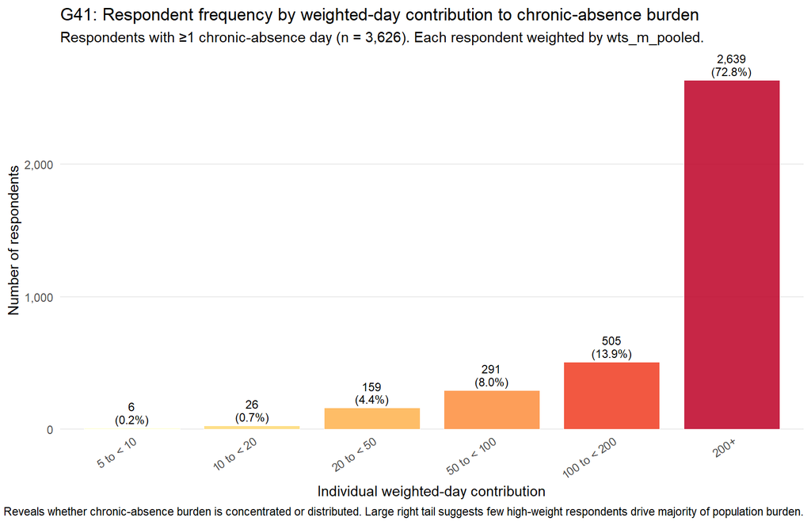

G41 validation table: respondent frequency and burden contribution by weighted-day bin

| Weighted-day bin | Respondent count | % of respondents | Total burden (weighted days) | % of total burden | Cumulative % burden |
| --- | --- | --- | --- | --- | --- |
| 5 to < 10 | 6 | 0.2% | 41 | 0.0% | 0.0% |
| 10 to < 20 | 26 | 0.7% | 419 | 0.0% | 0.0% |
| 20 to < 50 | 159 | 4.4% | 5754 | 0.1% | 0.1% |
| 50 to < 100 | 291 | 8.0% | 21929 | 0.3% | 0.4% |
| 100 to < 200 | 505 | 13.9% | 74229 | 1.1% | 1.6% |
| 200+ | 2,639 | 72.8% | 6425712 | 98.4% | 100.0% |

### G41 Validation

**Reading the validation table**: - **Respondent count**: Sample size in each bin (should sum to total chronic reporters). - **% of respondents**: What fraction of chronic reporters are in this bin. - **Total burden (weighted days)**: Sum of weighted days for respondents in this bin. - **% of total burden**: What fraction of all population chronic-absence burden comes from this bin. - **Cumulative % burden**: Running total — reveals the 80/20 rule for chronic absence. For example, if 10% of respondents account for 50% of burden, chronic absence is moderately concentrated.

**Next step** (if included): G42 could show the same data as a weighted histogram, where bar height represents burden contribution rather than respondent count, revealing burden skew.

# Session Info

```
Rendered: 2026-08-01 07:36:21
```